# Group Case 1 — BDO Unibank (BDO) Comprehensive Financial Regression Analysis

Preparing the Monthly Research Dataset for Baseline Multiple Linear Regression

FINARTS C01 — Group 1

2026-11-05

- Aragon, Enrique Miguel
- Lim, Andrei Gyles
- Millares, Brendan
- Quiazon, Erin

```r
# Download from December 2017 in order to properly compute January 2018 values
download_from <- as.Date("2017-12-01")
download_to   <- as.Date("2025-12-31")

# The sample itself runs from 2018-2025
sample_start <- as.Date("2018-01-01")
sample_end   <- as.Date("2025-12-01")

# Local file containing the other variables needed for later analysis. This is pre-transformed in Google Sheets for convenience (more details to follow)
local_file <- file.path("local_data.csv")
```

# Section 1 — Data Understanding and Preparation

## Section 1.1 - Candidate Regressors

This table reproduces the case brief. The **Source route** column determines whether a series is downloaded automatically or imported from the local file.

```r
variable_dictionary <- tribble(
  ~`#`, ~Candidate_Regressor,                 ~Dataset_Code,                  ~Transformation,           ~Source,                        ~Route,
  0,    "BDO return (DEPENDENT)", "BDO_return",                   "Monthly log return",      "Investing.com (price history)",    "Local CSV",
  1,    "PSEi return",                        "PSEI_return",                  "Monthly log return",      "Investing.com (price history)",    "Local CSV",
  2,    "BSP RRP rate change",                "BSP_RRP",               "Month-end first difference", "BSP",                         "Local CSV",
  3,    "PH 10Y gov't-yield change",          "PH_10Y_Yield",                "Month-end first difference", "Investing.com",         "Local CSV",
  4,    "USD/PHP change",                     "USD_PHP_Change",               "Monthly log change",      "BSP monthly FX / Yahoo (PHP=X)", "Download via GetSymbols",
  5,    "CPI inflation",                      "CPI",                   "YoY % change",            "PSA",                 "Local CSV",
  6,    "M3 growth",                          "---",                    "YoY % growth",            "---",       "Omitted",
  7,    "OFW remittance growth",              "OFW_remittances",       "YoY % growth",            "BSP",           "Local CSV",
  8,    "Manufacturing-production growth",    "manufacturing_prod_growth", "YoY % growth",         "PSA MISSI",                    "Local CSV",
  9,    "WTI return",                         "WTI_Return",                   "Monthly log return",      "FRED DCOILWTICO",              "Download via GetSymbols",
  10,   "VIX",                                "VIX",                          "Monthly average",         "FRED VIXCLS",                  "Download via GetSymbols"
)

variable_dictionary |>
  research_flextable()
```

| # | Candidate_Regressor | Dataset_Code | Transformation | Source | Route |
| --- | --- | --- | --- | --- | --- |
| 0 | BDO return (DEPENDENT) | BDO_return | Monthly log return | Investing.com (price history) | Local CSV |
| 1 | PSEi return | PSEI_return | Monthly log return | Investing.com (price history) | Local CSV |
| 2 | BSP RRP rate change | BSP_RRP | Month-end first difference | BSP | Local CSV |
| 3 | PH 10Y gov't-yield change | PH_10Y_Yield | Month-end first difference | Investing.com | Local CSV |
| 4 | USD/PHP change | USD_PHP_Change | Monthly log change | BSP monthly FX / Yahoo (PHP=X) | Download via GetSymbols |
| 5 | CPI inflation | CPI | YoY % change | PSA | Local CSV |
| 6 | M3 growth | --- | YoY % growth | --- | Omitted |
| 7 | OFW remittance growth | OFW_remittances | YoY % growth | BSP | Local CSV |
| 8 | Manufacturing-production growth | manufacturing_prod_growth | YoY % growth | PSA MISSI | Local CSV |
| 9 | WTI return | WTI_Return | Monthly log return | FRED DCOILWTICO | Download via GetSymbols |
| 10 | VIX | VIX | Monthly average | FRED VIXCLS | Download via GetSymbols |

The time range for all candidate regressors spans from January 1, 2018, until December 31, 2025. However, for regressors where a Year-on-Year growth transformation is required, 2017 data was used to compute for 2018 values.

Due to inconsistency in pulling data from the API, the monthly log returns for PSEi were instead computed from raw data taken from Investing.com. Additionally, due to a difficulty in procuring consistent, tabular M3 growth data in the Philippines (official reports from the BSP typically only displayed them in graphical form), the regressor was ommitted from the model.

## Section 1.2 — Downloading USD/PHP from Yahoo Finance

Since BDO and PSEi data are taken from a local file, only USD/PHP is still downloaded from Yahoo Finance. The helper below returns `NULL` (instead of crashing the whole document) if a download fails, so the problem is easy to diagnose.

```r
safe_get <- function(symbol, src) {
  tryCatch(
    suppressWarnings(
      getSymbols(symbol, src = src,
                 from = download_from, to = download_to,
                 auto.assign = FALSE)
    ),
    error = function(e) {
      message("Download failed for ", symbol, " (", src, "): ", conditionMessage(e))
      NULL
    }
  )
}

# Use the adjusted close when it exists (equities); otherwise the close (index, FX)
price_series <- function(x) {
  if (is.null(x)) return(NULL)
  if (has.Ad(x)) Ad(x) else Cl(x)
}

usdphp_raw <- safe_get("PHP=X", "yahoo")   # USD/PHP exchange rate (PHP per USD)
usdphp_px  <- price_series(usdphp_raw)
```

## Section 1.3 — Download Global Variables from FRED

Using the safe_get function defined in the previous code block, we download the VIX and RTI raw data.

```r
vix_raw <- safe_get("VIXCLS",      "FRED")   # CBOE VIX, daily close
wti_raw <- safe_get("DCOILWTICO",  "FRED")   # WTI crude oil, daily spot
```

## Section 1.4 — Convert the Downloaded Series to a Common Monthly Key

Every series is converted to have a year-month key (e.g., “Jan 2018”) **before** joining. This prevents random observation loss and also ensures consistency across each table.

```r
monthly_df_xts <- function(x, name, how = c("last", "mean")) {
  how <- match.arg(how)
  if (is.null(x)) return(NULL)

  tibble(
    date  = as.Date(index(x)),
    value = as.numeric(x[, 1])
  ) |>
    filter(is.finite(value)) |>
    arrange(date) |>
    mutate(month = as.yearmon(date)) |>
    group_by(month) |>
    summarise(
      value = if (how == "last") dplyr::last(value) else mean(value),
      .groups = "drop"
    ) |>
    rename(!!name := value)
}

# This gets the monthly average of the USD/PHP conversion rate, VIX, and WTI
usdphp_df <- monthly_df_xts(usdphp_px, "USD_PHP", how = "mean")
vix_df    <- monthly_df_xts(vix_raw,   "VIX",     how = "mean")
wti_df    <- monthly_df_xts(wti_raw,   "WTI",     how = "mean")
```

```r
# View the first few rows of the monthly aggregated data
head(usdphp_df)
```

```
# A tibble: 6 × 2
  month     USD_PHP
  <yearmon>   <dbl>
1 Dec 2017     50.2
2 Jan 2018     50.4
3 Feb 2018     51.8
4 Mar 2018     52.0
5 Apr 2018     52.0
6 May 2018     52.2
```

```r
head(vix_df)
```

```
# A tibble: 6 × 2
  month       VIX
  <yearmon> <dbl>
1 Dec 2017   10.3
2 Jan 2018   11.1
3 Feb 2018   22.5
4 Mar 2018   19.0
5 Apr 2018   18.3
6 May 2018   14.1
```

```r
head(wti_df)
```

```
# A tibble: 6 × 2
  month       WTI
  <yearmon> <dbl>
1 Dec 2017   57.9
2 Jan 2018   63.7
3 Feb 2018   62.2
4 Mar 2018   62.7
5 Apr 2018   66.3
6 May 2018   70.0
```

## Section 1.5 — Local CSV Loading and Transformations

For easier processing, the local CSV already contains data that has pre-transformed following the specifications per variable. Again, M3 growth is omitted from this dataset because no usable data could be found online. For convenience, all of the data taken locally was brought into one large CSV file containing the transformed data.

The contents of the raw data of each variable and how they were transformed are as follows:

```r
csv_regressors <- tribble(
  ~Candidate_Regressor,                 ~Raw_Data,                  ~Transformation,           ~Source,                        ~Initial_Data,
    "BDO return (DEPENDENT)", "Price for every trading date in the time range", "Monthly log return",      "Investing.com (price return)",    "The natural log of the current month's last trading day is subtracted from the natural log of the previous month's last trading day.",

    "PSEi return", "Price for every trading date in the time range",  "Monthly log return",      "Investing.com (price history)",    "The natural log of the current month's last trading day is subtracted from the natural log of the previous month's last trading day.",

    "BSP RRP rate change", "A list of every announcement within the time range regarding a change in the BSP RRP rate.",               "Month-end first difference", "BSP", "If a month has an indicated change in rate from the announcement, that respective month has a value. Otherwise, it is set to 0.",

      "PH 10Y gov't-yield change",          "Price for every trading date in the time range",                "Month-end first difference", "Investing.com",   "Current month last day minus previous month last day",

      "CPI inflation",                      "A table containing all the necessary YoY% change in CPI",                   "YoY % change",            "PSA",    "The data had to be manually transposed, thoough the results were pre-computed",

      "OFW remittance growth",              "Monthly OFW remittance in levels of 1 million USD",       "YoY % growth",            "BSP",           "YoY% growth was computed using a month's current-year performance against its performance in the previous year.",

      "Manufacturing-production growth",    "Raw MISSI data per month within the time range", "YoY % growth",         "PSA MISSI", "Data was transposed into a vertical format as the original data was horizontal."
)

csv_regressors |>
  research_flextable()
```

| Candidate_Regressor | Raw_Data | Transformation | Source | Initial_Data |
| --- | --- | --- | --- | --- |
| BDO return (DEPENDENT) | Price for every trading date in the time range | Monthly log return | Investing.com (price return) | The natural log of the current month's last trading day is subtracted from the natural log of the previous month's last trading day. |
| PSEi return | Price for every trading date in the time range | Monthly log return | Investing.com (price history) | The natural log of the current month's last trading day is subtracted from the natural log of the previous month's last trading day. |
| BSP RRP rate change | A list of every announcement within the time range regarding a change in the BSP RRP rate. | Month-end first difference | BSP | If a month has an indicated change in rate from the announcement, that respective month has a value. Otherwise, it is set to 0. |
| PH 10Y gov't-yield change | Price for every trading date in the time range | Month-end first difference | Investing.com | Current month last day minus previous month last day |
| CPI inflation | A table containing all the necessary YoY% change in CPI | YoY % change | PSA | The data had to be manually transposed, thoough the results were pre-computed |
| OFW remittance growth | Monthly OFW remittance in levels of 1 million USD | YoY % growth | BSP | YoY% growth was computed using a month's current-year performance against its performance in the previous year. |
| Manufacturing-production growth | Raw MISSI data per month within the time range | YoY % growth | PSA MISSI | Data was transposed into a vertical format as the original data was horizontal. |

Since the CSV already contains pre-transformed data, the only step left is turning the `month` label into a year-month key so it can be joined to the downloaded data.

```r
if (!file.exists(local_file)) {
  stop("Cannot find '", local_file, "'. Place it in the same folder as this .Rmd.")
}

local_df <- readr::read_csv(local_file, show_col_types = FALSE) |>
  mutate(month = as.yearmon(month, format = "%b %Y"))

stopifnot(!anyNA(local_df$month), !anyDuplicated(local_df$month))

head(local_df)
```

```
# A tibble: 6 × 8
  month     BDO_return PSEI_return BSP_RRP PH_10Y_Yield   CPI OFW_remittance
  <yearmon>      <dbl>       <dbl>   <dbl>        <dbl> <dbl>          <dbl>
1 Jan 2018      -6.95         2.37    0           0.508   4.4           9.68
2 Feb 2018       1.81        -3.35    0           0.527   4.5           4.52
3 Mar 2018     -11.4         -6.02    0          -0.734   5.2          -9.75
4 Apr 2018      -5.39        -2.03    0           0.203   5.2          12.7
5 May 2018      -0.922       -4.21    0.25       -0.104   5             6.88
6 Jun 2018      -3.90        -4.13    0.25        0.323   5.9          -4.46
# ℹ 1 more variable: manafactuting_prod_growth <dbl>
```

## Section 1.6 — Log Changes for the Downloaded Series

In order to match the specifications, USD/PHP and WTI use `log(level_t) - log(level_{t-1})` to compute for monthly log return. VIX, on the other hand,only computes for the monthly average. December 2017 is in the downloaded data only to supply the base for January 2018 and is dropped by the join.

```r
market_list <- list(USD_PHP = usdphp_df, VIX = vix_df, WTI = wti_df)

failed <- names(Filter(is.null, market_list))
if (length(failed) > 0) {
  stop("These downloads failed, so the dataset cannot be built: ",
       paste(failed, collapse = ", "))
}

log_change <- function(x) log(x) - dplyr::lag(log(x))

market_df <- usdphp_df |>
  full_join(vix_df, by = "month") |>
  full_join(wti_df, by = "month") |>
  arrange(month) |>
  mutate(
    USD_PHP_Change = log_change(USD_PHP),
    WTI_Return     = log_change(WTI)
  ) |>
  select(month, USD_PHP_Change, WTI_Return, VIX)

head(market_df)
```

```
# A tibble: 6 × 4
  month     USD_PHP_Change WTI_Return   VIX
  <yearmon>          <dbl>      <dbl> <dbl>
1 Dec 2017       NA          NA        10.3
2 Jan 2018        0.00408     0.0958   11.1
3 Feb 2018        0.0262     -0.0233   22.5
4 Mar 2018        0.00503     0.00793  19.0
5 Apr 2018       -0.000395    0.0547   18.3
6 May 2018        0.00357     0.0547   14.1
```

## Section 1.7 — Join the Downloaded Data with the CSV Data

Each table is joined to one another using a left join on tthe year-month key.

```r
month_spine <- tibble(
  month = as.yearmon(seq(sample_start, sample_end, by = "month"))
)

analysis_df <- month_spine |>
  left_join(local_df,  by = "month") |>
  left_join(market_df, by = "month")

analysis_df |>
  head(12) |>
  cobalt_kable(caption = "Analysis Dataset (first 12 months)")
```

Analysis Dataset (first 12 months)

| month | BDO_return | PSEI_return | BSP_RRP | PH_10Y_Yield | CPI | OFW_remittance | manafactuting_prod_growth | USD_PHP_Change | WTI_Return | VIX |
| --- | --- | --- | --- | --- | --- | --- | --- | --- | --- | --- |
| Jan 2018 | -6.9456 | 2.3738 | 0.00 | 0.508 | 4.4 | 9.682 | 10.43 | 0.0041 | 0.0958 | 11.0624 |
| Feb 2018 | 1.8093 | -3.3499 | 0.00 | 0.527 | 4.5 | 4.518 | 11.51 | 0.0262 | -0.0233 | 22.4647 |
| Mar 2018 | -11.4083 | -6.0238 | 0.00 | -0.734 | 5.2 | -9.751 | 6.38 | 0.0050 | 0.0079 | 19.0238 |
| Apr 2018 | -5.3888 | -2.0328 | 0.00 | 0.203 | 5.2 | 12.674 | 14.84 | -0.0004 | 0.0547 | 18.2676 |
| May 2018 | -0.9224 | -4.2063 | 0.25 | -0.104 | 5.0 | 6.883 | 8.86 | 0.0036 | 0.0547 | 14.1245 |
| Jun 2018 | -3.9024 | -4.1323 | 0.25 | 0.323 | 5.9 | -4.459 | 11.69 | 0.0170 | -0.0305 | 13.6781 |
| Jul 2018 | 5.0450 | 6.4374 | 0.00 | 0.123 | 6.6 | 5.169 | 14.45 | 0.0046 | 0.0448 | 13.1476 |
| Aug 2018 | -1.4488 | 2.3663 | 0.50 | -0.175 | 7.1 | -0.920 | 7.85 | -0.0023 | -0.0421 | 12.5470 |
| Sep 2018 | -8.2408 | -7.6547 | 0.50 | 0.843 | 6.3 | 2.333 | 5.25 | 0.0126 | 0.0315 | 12.9105 |
| Oct 2018 | 2.1470 | -1.8941 | 0.00 | 0.737 | 6.0 | 8.747 | 6.52 | -0.0006 | 0.0073 | 19.3522 |
| Nov 2018 | 6.1775 | 3.1373 | 0.25 | -0.915 | 5.5 | 2.829 | 4.50 | -0.0213 | -0.2167 | 19.3890 |
| Dec 2018 | 0.4541 | 1.3236 | 0.00 | 0.011 | 4.7 | 3.940 | -12.02 | 0.0006 | -0.1400 | 24.9532 |

```r
tibble(
  Check = c("Rows (expected 96)", "Columns (month + dependent + regressors)",
            "First month", "Last month", "Total missing values"),
  Result = c(nrow(analysis_df), ncol(analysis_df),
             format(min(analysis_df$month)), format(max(analysis_df$month)),
             sum(is.na(analysis_df)))
) |>
  cobalt_kable(caption = "Join Checks")
```

Join Checks

| Check | Result |
| --- | --- |
| Rows (expected 96) | 96 |
| Columns (month + dependent + regressors) | 11 |
| First month | Jan 2018 |
| Last month | Dec 2025 |
| Total missing values | 0 |

```r
# Missing values per column (all should be 0)
analysis_df |>
  summarise(across(everything(), ~ sum(is.na(.x)))) |>
  pivot_longer(everything(), names_to = "Variable", values_to = "Missing") |>
  cobalt_kable(caption = "Missing Values by Variable")
```

Missing Values by Variable

| Variable | Missing |
| --- | --- |
| month | 0 |
| BDO_return | 0 |
| PSEI_return | 0 |
| BSP_RRP | 0 |
| PH_10Y_Yield | 0 |
| CPI | 0 |
| OFW_remittance | 0 |
| manafactuting_prod_growth | 0 |
| USD_PHP_Change | 0 |
| WTI_Return | 0 |
| VIX | 0 |

```r
view(analysis_df)
```

## Section 1.8 - Descriptive Statistics

In order to better understand the multi-faceted nature of the data, we calculate descriptive statistics pertaining to each variable.

```r
descriptive_table <- tibble(

  Statistic = c(
    "Mean",
    "Median",
    "Trimmed Mean",
    "Standard Deviation",
    "Variance",
    "Minimum",
    "Q1",
    "Q3",
    "Maximum",
    "Range",
    "Interquartile Range",
    "Coefficient of Variation",
    "Skewness",
    "Kurtosis",
    "Observations"
  ),

  BDO_return = c(
    mean(analysis_df$BDO_return, na.rm = TRUE),
    median(analysis_df$BDO_return, na.rm = TRUE),
    mean(analysis_df$BDO_return, trim = 0.05, na.rm = TRUE),
    sd(analysis_df$BDO_return, na.rm = TRUE),
    var(analysis_df$BDO_return, na.rm = TRUE),
    min(analysis_df$BDO_return, na.rm = TRUE),
    quantile(analysis_df$BDO_return, 0.25, na.rm = TRUE),
    quantile(analysis_df$BDO_return, 0.75, na.rm = TRUE),
    max(analysis_df$BDO_return, na.rm = TRUE),
    diff(range(analysis_df$BDO_return, na.rm = TRUE)),
    IQR(analysis_df$BDO_return, na.rm = TRUE),
    sd(analysis_df$BDO_return, na.rm = TRUE) /
      mean(analysis_df$BDO_return, na.rm = TRUE),
    skewness(analysis_df$BDO_return, na.rm = TRUE),
    kurtosis(analysis_df$BDO_return, na.rm = TRUE),
    sum(!is.na(analysis_df$BDO_return))
  ),

  PSEI_return = c(
    mean(analysis_df$PSEI_return, na.rm = TRUE),
    median(analysis_df$PSEI_return, na.rm = TRUE),
    mean(analysis_df$PSEI_return, trim = 0.05, na.rm = TRUE),
    sd(analysis_df$PSEI_return, na.rm = TRUE),
    var(analysis_df$PSEI_return, na.rm = TRUE),
    min(analysis_df$PSEI_return, na.rm = TRUE),
    quantile(analysis_df$PSEI_return, 0.25, na.rm = TRUE),
    quantile(analysis_df$PSEI_return, 0.75, na.rm = TRUE),
    max(analysis_df$PSEI_return, na.rm = TRUE),
    diff(range(analysis_df$PSEI_return, na.rm = TRUE)),
    IQR(analysis_df$PSEI_return, na.rm = TRUE),
    sd(analysis_df$PSEI_return, na.rm = TRUE) /
      mean(analysis_df$PSEI_return, na.rm = TRUE),
    skewness(analysis_df$PSEI_return, na.rm = TRUE),
    kurtosis(analysis_df$PSEI_return, na.rm = TRUE),
    sum(!is.na(analysis_df$PSEI_return))
  ),

  BSP_RRP = c(
    mean(analysis_df$BSP_RRP, na.rm = TRUE),
    median(analysis_df$BSP_RRP, na.rm = TRUE),
    mean(analysis_df$BSP_RRP, trim = 0.05, na.rm = TRUE),
    sd(analysis_df$BSP_RRP, na.rm = TRUE),
    var(analysis_df$BSP_RRP, na.rm = TRUE),
    min(analysis_df$BSP_RRP, na.rm = TRUE),
    quantile(analysis_df$BSP_RRP, 0.25, na.rm = TRUE),
    quantile(analysis_df$BSP_RRP, 0.75, na.rm = TRUE),
    max(analysis_df$BSP_RRP, na.rm = TRUE),
    diff(range(analysis_df$BSP_RRP, na.rm = TRUE)),
    IQR(analysis_df$BSP_RRP, na.rm = TRUE),
    sd(analysis_df$BSP_RRP, na.rm = TRUE) /
      mean(analysis_df$BSP_RRP, na.rm = TRUE),
    skewness(analysis_df$BSP_RRP, na.rm = TRUE),
    kurtosis(analysis_df$BSP_RRP, na.rm = TRUE),
    sum(!is.na(analysis_df$BSP_RRP))
  ),
  PH_10Y_Yield = c(
    mean(analysis_df$PH_10Y_Yield, na.rm = TRUE),
    median(analysis_df$PH_10Y_Yield, na.rm = TRUE),
    mean(analysis_df$PH_10Y_Yield, trim = 0.05, na.rm = TRUE),
    sd(analysis_df$PH_10Y_Yield, na.rm = TRUE),
    var(analysis_df$PH_10Y_Yield, na.rm = TRUE),
    min(analysis_df$PH_10Y_Yield, na.rm = TRUE),
    quantile(analysis_df$PH_10Y_Yield, 0.25, na.rm = TRUE),
    quantile(analysis_df$PH_10Y_Yield, 0.75, na.rm = TRUE),
    max(analysis_df$PH_10Y_Yield, na.rm = TRUE),
    diff(range(analysis_df$PH_10Y_Yield, na.rm = TRUE)),
    IQR(analysis_df$PH_10Y_Yield, na.rm = TRUE),
    sd(analysis_df$PH_10Y_Yield, na.rm = TRUE) /
      mean(analysis_df$PH_10Y_Yield, na.rm = TRUE),
    skewness(analysis_df$PH_10Y_Yield, na.rm = TRUE),
    kurtosis(analysis_df$PH_10Y_Yield, na.rm = TRUE),
    sum(!is.na(analysis_df$PH_10Y_Yield))
  ),
  CPI = c(
    mean(analysis_df$CPI, na.rm = TRUE),
    median(analysis_df$CPI, na.rm = TRUE),
    mean(analysis_df$CPI, trim = 0.05, na.rm = TRUE),
    sd(analysis_df$CPI, na.rm = TRUE),
    var(analysis_df$CPI, na.rm = TRUE),
    min(analysis_df$CPI, na.rm = TRUE),
    quantile(analysis_df$CPI, 0.25, na.rm = TRUE),
    quantile(analysis_df$CPI, 0.75, na.rm = TRUE),
    max(analysis_df$CPI, na.rm = TRUE),
    diff(range(analysis_df$CPI, na.rm = TRUE)),
    IQR(analysis_df$CPI, na.rm = TRUE),
    sd(analysis_df$CPI, na.rm = TRUE) /
      mean(analysis_df$CPI, na.rm = TRUE),
    skewness(analysis_df$CPI, na.rm = TRUE),
    kurtosis(analysis_df$CPI, na.rm = TRUE),
    sum(!is.na(analysis_df$CPI))
  ),
  OFW_remittance = c(
    mean(analysis_df$OFW_remittance, na.rm = TRUE),
    median(analysis_df$OFW_remittance, na.rm = TRUE),
    mean(analysis_df$OFW_remittance, trim = 0.05, na.rm = TRUE),
    sd(analysis_df$OFW_remittance, na.rm = TRUE),
    var(analysis_df$OFW_remittance, na.rm = TRUE),
    min(analysis_df$OFW_remittance, na.rm = TRUE),
    quantile(analysis_df$OFW_remittance, 0.25, na.rm = TRUE),
    quantile(analysis_df$OFW_remittance, 0.75, na.rm = TRUE),
    max(analysis_df$OFW_remittance, na.rm = TRUE),
    diff(range(analysis_df$OFW_remittance, na.rm = TRUE)),
    IQR(analysis_df$OFW_remittance, na.rm = TRUE),
    sd(analysis_df$OFW_remittance, na.rm = TRUE) /
      mean(analysis_df$OFW_remittance, na.rm = TRUE),
    skewness(analysis_df$OFW_remittance, na.rm = TRUE),
    kurtosis(analysis_df$OFW_remittance, na.rm = TRUE),
    sum(!is.na(analysis_df$OFW_remittance))
  ),
  manafactuting_prod_growth = c(
    mean(analysis_df$manafactuting_prod_growth, na.rm = TRUE),
    median(analysis_df$manafactuting_prod_growth, na.rm = TRUE),
    mean(analysis_df$manafactuting_prod_growth, trim = 0.05, na.rm = TRUE),
    sd(analysis_df$manafactuting_prod_growth, na.rm = TRUE),
    var(analysis_df$manafactuting_prod_growth, na.rm = TRUE),
    min(analysis_df$manafactuting_prod_growth, na.rm = TRUE),
    quantile(analysis_df$manafactuting_prod_growth, 0.25, na.rm = TRUE),
    quantile(analysis_df$manafactuting_prod_growth, 0.75, na.rm = TRUE),
    max(analysis_df$manafactuting_prod_growth, na.rm = TRUE),
    diff(range(analysis_df$manafactuting_prod_growth, na.rm = TRUE)),
    IQR(analysis_df$manafactuting_prod_growth, na.rm = TRUE),
    sd(analysis_df$manafactuting_prod_growth, na.rm = TRUE) /
      mean(analysis_df$manafactuting_prod_growth, na.rm = TRUE),
    skewness(analysis_df$manafactuting_prod_growth, na.rm = TRUE),
    kurtosis(analysis_df$manafactuting_prod_growth, na.rm = TRUE),
    sum(!is.na(analysis_df$manafactuting_prod_growth))
  ),
  USD_PHP_Change = c(
    mean(analysis_df$USD_PHP_Change, na.rm = TRUE),
    median(analysis_df$USD_PHP_Change, na.rm = TRUE),
    mean(analysis_df$USD_PHP_Change, trim = 0.05, na.rm = TRUE),
    sd(analysis_df$USD_PHP_Change, na.rm = TRUE),
    var(analysis_df$USD_PHP_Change, na.rm = TRUE),
    min(analysis_df$USD_PHP_Change, na.rm = TRUE),
    quantile(analysis_df$USD_PHP_Change, 0.25, na.rm = TRUE),
    quantile(analysis_df$USD_PHP_Change, 0.75, na.rm = TRUE),
    max(analysis_df$USD_PHP_Change, na.rm = TRUE),
    diff(range(analysis_df$USD_PHP_Change, na.rm = TRUE)),
    IQR(analysis_df$USD_PHP_Change, na.rm = TRUE),
    sd(analysis_df$USD_PHP_Change, na.rm = TRUE) /
      mean(analysis_df$USD_PHP_Change, na.rm = TRUE),
    skewness(analysis_df$USD_PHP_Change, na.rm = TRUE),
    kurtosis(analysis_df$USD_PHP_Change, na.rm = TRUE),
    sum(!is.na(analysis_df$USD_PHP_Change))
  ),
  WTI_Return = c(
    mean(analysis_df$WTI_Return, na.rm = TRUE),
    median(analysis_df$WTI_Return, na.rm = TRUE),
    mean(analysis_df$WTI_Return, trim = 0.05, na.rm = TRUE),
    sd(analysis_df$WTI_Return, na.rm = TRUE),
    var(analysis_df$WTI_Return, na.rm = TRUE),
    min(analysis_df$WTI_Return, na.rm = TRUE),
    quantile(analysis_df$WTI_Return, 0.25, na.rm = TRUE),
    quantile(analysis_df$WTI_Return, 0.75, na.rm = TRUE),
    max(analysis_df$WTI_Return, na.rm = TRUE),
    diff(range(analysis_df$WTI_Return, na.rm = TRUE)),
    IQR(analysis_df$WTI_Return, na.rm = TRUE),
    sd(analysis_df$WTI_Return, na.rm = TRUE) /
      mean(analysis_df$WTI_Return, na.rm = TRUE),
    skewness(analysis_df$WTI_Return, na.rm = TRUE),
    kurtosis(analysis_df$WTI_Return, na.rm = TRUE),
    sum(!is.na(analysis_df$WTI_Return))
  ),
  VIX = c(
    mean(analysis_df$VIX, na.rm = TRUE),
    median(analysis_df$VIX, na.rm = TRUE),
    mean(analysis_df$VIX, trim = 0.05, na.rm = TRUE),
    sd(analysis_df$VIX, na.rm = TRUE),
    var(analysis_df$VIX, na.rm = TRUE),
    min(analysis_df$VIX, na.rm = TRUE),
    quantile(analysis_df$VIX, 0.25, na.rm = TRUE),
    quantile(analysis_df$VIX, 0.75, na.rm = TRUE),
    max(analysis_df$VIX, na.rm = TRUE),
    diff(range(analysis_df$VIX, na.rm = TRUE)),
    IQR(analysis_df$VIX, na.rm = TRUE),
    sd(analysis_df$VIX, na.rm = TRUE) /
      mean(analysis_df$VIX, na.rm = TRUE),
    skewness(analysis_df$VIX, na.rm = TRUE),
    kurtosis(analysis_df$VIX, na.rm = TRUE),
    sum(!is.na(analysis_df$VIX))
  )
)


descriptive_table |>
  research_flextable()
```

| Statistic | BDO_return | PSEI_return | BSP_RRP | PH_10Y_Yield | CPI | OFW_remittance | manafactuting_prod_growth | USD_PHP_Change | WTI_Return | VIX |
| --- | --- | --- | --- | --- | --- | --- | --- | --- | --- | --- |
| Mean | -0.007855208 | -0.3608042 | 0.015625000 | 0.003489583 | 3.5885417 | 3.136917 | 20.851875 | 0.00163774608 | 0.00001632315 | 19.7318676 |
| Median | 0.470750000 | 0.2929000 | 0.000000000 | 0.019000000 | 2.9000000 | 3.182500 | 1.540000 | -0.00005642107 | 0.00528927282 | 18.3354762 |
| Trimmed Mean | 0.230913636 | -0.1085000 | 0.008522727 | 0.013897727 | 3.5045455 | 3.441932 | 5.096818 | 0.00143568956 | 0.00361016773 | 19.1270806 |
| Standard Deviation | 7.094260944 | 5.1695658 | 0.220085211 | 0.425446193 | 1.9721679 | 4.503116 | 103.291531 | 0.01351463236 | 0.12560724099 | 6.7633900 |
| Variance | 50.328538338 | 26.7244103 | 0.048437500 | 0.181004463 | 3.8894463 | 20.278050 | 10,669.140287 | 0.00018264529 | 0.01577717899 | 45.7434449 |
| Minimum | -29.484200000 | -24.3439000 | -0.500000000 | -1.572000000 | 0.5000000 | -19.279000 | -82.170000 | -0.03442684726 | -0.56819107961 | 11.0623810 |
| Q1 | -4.086700000 | -3.0764500 | 0.000000000 | -0.197250000 | 2.2000000 | 2.505250 | -3.615000 | -0.00589924795 | -0.05006022755 | 15.4085755 |
| Q3 | 4.169200000 | 2.8353250 | 0.000000000 | 0.200000000 | 5.0250000 | 4.643250 | 6.935000 | 0.00839389806 | 0.05495505002 | 22.3967524 |
| Maximum | 15.015900000 | 9.7082000 | 0.750000000 | 0.872000000 | 8.7000000 | 13.105000 | 534.390000 | 0.04009122541 | 0.54585244137 | 57.7368182 |
| Range | 44.500100000 | 34.0521000 | 1.250000000 | 2.444000000 | 8.2000000 | 32.384000 | 616.560000 | 0.07451807267 | 1.11404352098 | 46.6744372 |
| Interquartile Range | 8.255900000 | 5.9117750 | 0.000000000 | 0.397250000 | 2.8250000 | 2.138000 | 10.550000 | 0.01429314601 | 0.10501527757 | 6.9881769 |
| Coefficient of Variation | -903.128299434 | -14.3278993 | 14.085453489 | 121.918909009 | 0.5495736 | 1.435523 | 4.953585 | 8.25197050204 | 7,695.03539285548 | 0.3427648 |
| Skewness | -0.750169056 | -1.2328958 | 0.902216400 | -0.522117075 | 0.7767916 | -2.114181 | 3.785555 | 0.35089032370 | -0.86892515823 | 2.3678952 |
| Kurtosis | 2.357107702 | 3.7410914 | 2.485343926 | 1.315239195 | -0.3147810 | 9.028035 | 14.572890 | 0.55711174395 | 9.73621146604 | 9.4983309 |
| Observations | 96.000000000 | 96.0000000 | 96.000000000 | 96.000000000 | 96.0000000 | 96.000000 | 96.000000 | 96.00000000000 | 96.00000000000 | 96.0000000 |

## Section 1.9 - Visualizations

While descriptive statistics offer numerical information about the data, this alone does not explain the nuances and trends of the data sufficiently. In order to gain a deeper understanding, we create relevant visualizations as seen below.

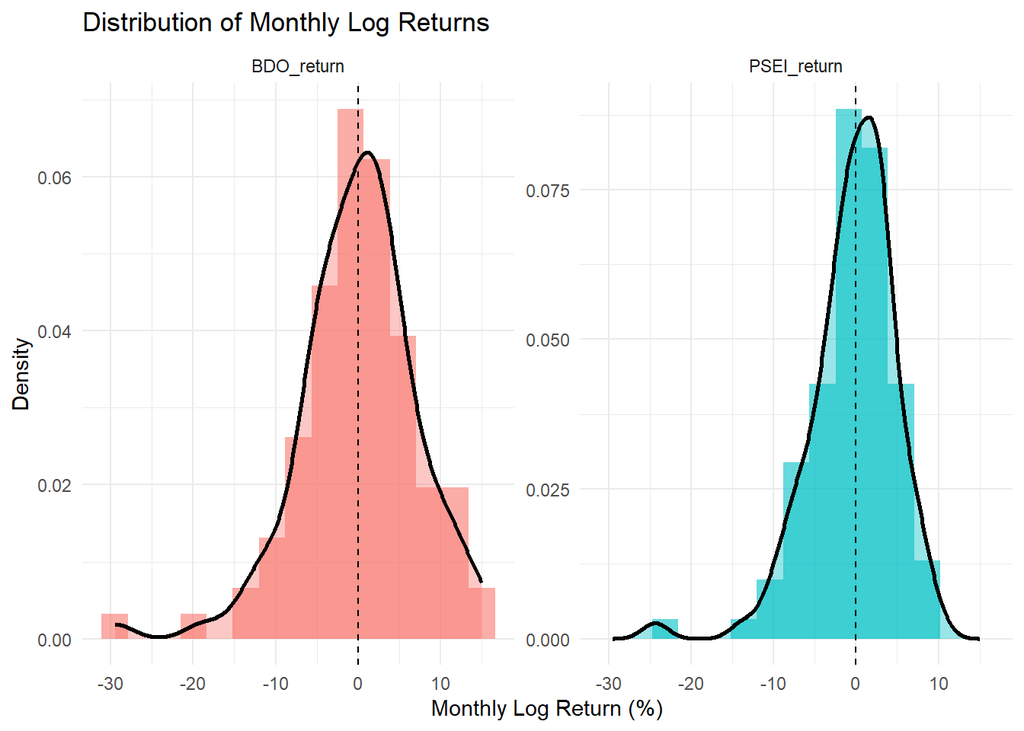

```r
returns_long <- analysis_df |>
  select(month, BDO_return, PSEI_return) |>
  pivot_longer(cols = c(BDO_return, PSEI_return),
               names_to = "Asset", values_to = "Return")

ggplot(returns_long, aes(x = Return, fill = Asset)) +
  geom_histogram(aes(y = after_stat(density)), bins = 15, alpha = 0.6, position = "identity") +
  geom_density(alpha = 0.4, linewidth = 1) +
  geom_vline(xintercept = 0, linetype = "dashed", color = "black") +
  facet_wrap(~ Asset, scales = "free_y") +
  labs(
    title = "Distribution of Monthly Log Returns",
    x = "Monthly Log Return (%)",
    y = "Density"
  ) +
  theme_minimal() +
  theme(legend.position = "none")
```

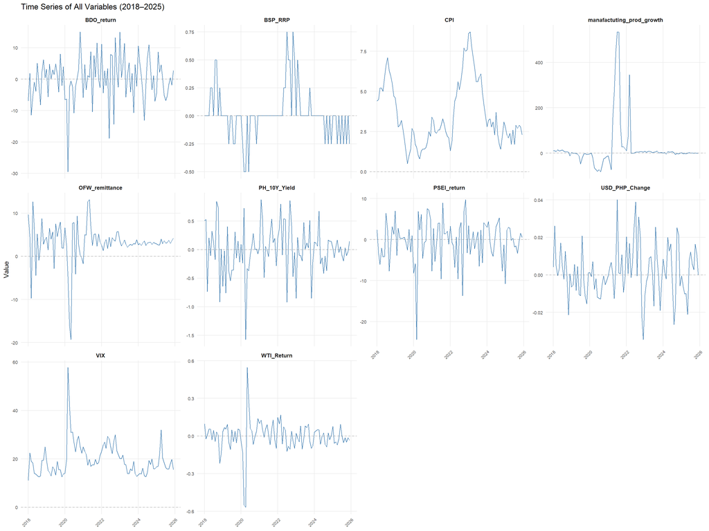

```r
all_vars_long <- analysis_df |>
  select(month, BDO_return, PSEI_return, BSP_RRP, PH_10Y_Yield,
         CPI, OFW_remittance, manafactuting_prod_growth,
         USD_PHP_Change, WTI_Return, VIX) |>
  pivot_longer(-month, names_to = "Variable", values_to = "Value")

ggplot(all_vars_long, aes(x = as.Date(month), y = Value)) +
  geom_line(color = "steelblue", linewidth = 0.5) +
  geom_hline(yintercept = 0, linetype = "dashed", color = "grey50", alpha = 0.5) +

  # Facet by variable and free the Y-axis so scales don't clash
  facet_wrap(~ Variable, scales = "free_y", ncol = 4) +

  labs(
    title = "Time Series of All Variables (2018–2025)",
    x = NULL,
    y = "Value"
  ) +
  theme_minimal() +
  theme(
    strip.text = element_text(face = "bold", size = 9),
    axis.text.x = element_text(angle = 45, hjust = 1, size = 7),
    axis.text.y = element_text(size = 7),
    panel.grid.minor = element_blank()
  )
```

# Section 2 — Baseline Multiple Linear Regression

A single baseline model using every available column as a regressor (M3 excluded), fitted on the full sample.

```r
dep_var <- "BDO_return"   # dependent variable: BDO monthly log return (column name in the local CSV)

model_data <- analysis_df |>
  select(-month) |>
  drop_na()

baseline_lm <- lm(reformulate(".", response = dep_var), data = model_data)

# --- Regression accuracy (in-sample) ---
tibble(
  Metric = c("Observations used", "R-squared", "Adjusted R-squared", "RMSE", "MAE"),
  Value  = c(nobs(baseline_lm),
             summary(baseline_lm)$r.squared,
             summary(baseline_lm)$adj.r.squared,
             sqrt(mean(residuals(baseline_lm)^2)),
             mean(abs(residuals(baseline_lm))))
) |>
  cobalt_kable(caption = "Baseline Linear Regression — Fit (in-sample)")
```

Baseline Linear Regression — Fit (in-sample)

| Metric | Value |
| --- | --- |
| Observations used | 96.0000 |
| R-squared | 0.6134 |
| Adjusted R-squared | 0.5730 |
| RMSE | 4.3878 |
| MAE | 3.4779 |

```r
coef(baseline_lm)
```

```
              (Intercept)               PSEI_return                   BSP_RRP
             0.1715732941              1.0407523713             -0.5526832478
             PH_10Y_Yield                       CPI            OFW_remittance
            -0.1097244088              0.3298283936              0.0796097556
manafactuting_prod_growth            USD_PHP_Change                WTI_Return
             0.0003631603             27.2440866180              2.8152617910
                      VIX
            -0.0648935870
```

The model’s equation is as follows:

$$\begin{aligned}
\text{BDO_return}_t = {} & \beta_0 + \beta_1\text{PSEi_return}_t +
\beta_2\text{BSP_RRP}_t + \beta_3\text{PH_10Y_Yield}_t \\
& + \beta_4\text{CPI}_t + \beta_5\text{OFW_remittance}_t +
\beta_6\text{Mfg_growth}_t \\
& + \beta_7\text{USD_PHP}_t + \beta_8\text{WTI_Return}_t +
\beta_9\text{VIX}_t + u_t
\end{aligned}$$

Using the coefficients, the updated regression equation is:

$$\begin{aligned}
\widehat{\text{BDO_return}}_t = {} & 0.1716 +
1.0408\text{PSEi_return}_t - 0.5527\text{BSP_RRP}_t -
0.1097\text{PH_10Y_Yield}_t \\
& + 0.3298\text{CPI}_t + 0.0796\text{OFW_remittance}_t +
0.0004\text{Mfg_growth}_t \\
& + 27.2441\text{USD_PHP}_t + 2.8153\text{WTI_Return}_t -
0.0649\text{VIX}_t
\end{aligned}$$

# Section 3 - Statistical Inference

Calculate coefficient tests, confidence intervals, effect sizes, and joint F-tests from `baseline_lm`.

## 3.1 Individual Coefficient Tests

Test each coefficient against zero (two-sided, 5% level) and extract its estimate, standard error, t-statistic, and p-value.

| Factor | Estimate | Std. error | t-statistic | p-value | Decision at 5% |
| --- | --- | --- | --- | --- | --- |
| Constant (intercept) | 0.1715732941 | 2.200267521 | 0.07797838 | 0.938026396234282 | Do not reject H0 |
| PSEi return | 1.0407523713 | 0.112749956 | 9.23062328 | 1.668771e-14 | Reject H0 |
| BSP policy-rate change | -0.5526832478 | 2.805428873 | -0.19700490 | 0.844288545552893 | Do not reject H0 |
| PH 10Y yield change | -0.1097244088 | 1.406460738 | -0.07801456 | 0.937997703837145 | Do not reject H0 |
| CPI inflation | 0.3298283936 | 0.312597872 | 1.05512041 | 0.29432545748118 | Do not reject H0 |
| OFW remittance growth | 0.0796097556 | 0.122061274 | 0.65221141 | 0.516004256651832 | Do not reject H0 |
| Manufacturing growth | 0.0003631603 | 0.004891659 | 0.07424071 | 0.940991265132295 | Do not reject H0 |
| USD/PHP log change | 27.2440866180 | 40.116996449 | 0.67911581 | 0.498888143495453 | Do not reject H0 |
| WTI log return | 2.8152617910 | 4.451779865 | 0.63239016 | 0.528809721364277 | Do not reject H0 |
| VIX | -0.0648935870 | 0.082222611 | -0.78924260 | 0.432140759716711 | Do not reject H0 |

## 3.2 Confidence Intervals and Parameter Uncertainty

Use `confint()` to obtain 95% coefficient intervals and check whether they include zero.

| Factor | Estimate | Lower 95% | Upper 95% | Includes zero? |
| --- | --- | --- | --- | --- |
| Constant (intercept) | 0.1715732941 | -4.202413774 | 4.54556036 | Yes |
| PSEi return | 1.0407523713 | 0.816612877 | 1.26489187 | No |
| BSP policy-rate change | -0.5526832478 | -6.129691268 | 5.02432477 | Yes |
| PH 10Y yield change | -0.1097244088 | -2.905675820 | 2.68622700 | Yes |
| CPI inflation | 0.3298283936 | -0.291595609 | 0.95125240 | Yes |
| OFW remittance growth | 0.0796097556 | -0.163040026 | 0.32225954 | Yes |
| Manufacturing growth | 0.0003631603 | -0.009361137 | 0.01008746 | Yes |
| USD/PHP log change | 27.2440866180 | -52.505862875 | 106.99403611 | Yes |
| WTI log return | 2.8152617910 | -6.034583682 | 11.66510726 | Yes |
| VIX | -0.0648935870 | -0.228346727 | 0.09855955 | Yes |

## 3.3 Statistical versus Economic Significance

Calculate one-standard-deviation effects and all nine predefined scenarios from the fitted coefficients.

| Factor | Factor SD | BDO change (pp) | % of BDO return SD | Significant at 5% |
| --- | --- | --- | --- | --- |
| PSEi return | 5.16956578 | 5.38023784 | 75.8393000 | Yes |
| BSP policy-rate change | 0.22008521 | -0.12163741 | 1.7145889 | No |
| PH 10Y yield change | 0.42544619 | -0.04668183 | 0.6580225 | No |
| CPI inflation | 1.97216791 | 0.65047697 | 9.1690590 | No |
| OFW remittance growth | 4.50311555 | 0.35849193 | 5.0532667 | No |
| Manufacturing growth | 103.29153057 | 0.03751138 | 0.5287567 | No |
| USD/PHP log change | 0.01351463 | 0.36819381 | 5.1900236 | No |
| WTI log return | 0.12560724 | 0.35361727 | 4.9845540 | No |
| VIX | 6.76339005 | -0.43890064 | 6.1867000 | No |

| Factor | Scenario | Scenario change | BDO change (pp) | Lower 95% (pp) | Upper 95% (pp) |
| --- | --- | --- | --- | --- | --- |
| PSEi return | +1 percentage point in market return | 1.000000000 | 1.040752371 | 0.81661288 | 1.2648919 |
| BSP policy-rate change | +0.25 percentage points in rate change | 0.250000000 | -0.138170812 | -1.53242282 | 1.2560812 |
| PH 10Y yield change | +0.25 percentage points in yield change | 0.250000000 | -0.027431102 | -0.72641895 | 0.6715568 |
| CPI inflation | +1 percentage point in YoY inflation | 1.000000000 | 0.329828394 | -0.29159561 | 0.9512524 |
| OFW remittance growth | +5 percentage points in YoY growth | 5.000000000 | 0.398048778 | -0.81520013 | 1.6112977 |
| Manufacturing growth | +10 percentage points in YoY growth | 10.000000000 | 0.003631603 | -0.09361137 | 0.1008746 |
| USD/PHP log change | +1% in the exchange-rate ratio (peso depreciation) | 0.009950331 | 0.271087676 | -0.52245071 | 1.0646261 |
| WTI log return | +10% in the oil-price ratio | 0.095310180 | 0.268323107 | -0.57515726 | 1.1118035 |
| VIX | +10 index points | 10.000000000 | -0.648935870 | -2.28346727 | 0.9855955 |

## 3.4 Joint Hypothesis Tests

Calculate the overall F-test and compare `market_lm` with `baseline_lm` using `anova()`.

| Joint test | F-statistic | Numerator df | Denominator df | p-value | Decision at 5% |
| --- | --- | --- | --- | --- | --- |
| Overall contribution of all factors | 15.1630849 | 9 | 86 | 1.814572e-14 | Reject H0 |
| Additional contribution beyond PSEi | 0.6789123 | 8 | 86 | 0.708821574188749 | Do not reject H0 |

# Section 4 - Model Evaluation and Comparison

Compare three nested models using fit criteria, in-sample errors, and F-tests.

## 4.1 Models Being Compared

Fit the domestic model and verify that all three models use the same observations.

List the factors added at each model stage.

| Model | Total factors | Factors added |
| --- | --- | --- |
| Market benchmark | 1 | PSEi return |
| Market + domestic conditions | 7 | BSP policy-rate change; PH 10Y yield change; USD/PHP log change; CPI inflation; OFW remittance growth; Manufacturing growth |
| Full baseline | 9 | WTI return; VIX |

M3 growth is not included because its data were unavailable.

## 4.2 Model Fit and Complexity

Calculate R-squared, adjusted R-squared, AIC, BIC, RMSE, and MAE for each model.

| Model | Observations | Factors | R-squared | Adjusted R-squared | AIC | BIC | RMSE | MAE |
| --- | --- | --- | --- | --- | --- | --- | --- | --- |
| Market benchmark | 96 | 1 | 0.5890133 | 0.5846411 | 568.2512 | 575.9443 | 4.524257 | 3.614109 |
| Market + domestic conditions | 96 | 7 | 0.6065962 | 0.5753028 | 576.0537 | 599.1328 | 4.426420 | 3.502131 |
| Full baseline | 96 | 9 | 0.6134271 | 0.5729718 | 578.3721 | 606.5800 | 4.387822 | 3.477909 |

## 4.3 Nested-Model Comparisons

Use `anova()` to test the additional domestic and global factors.

| Comparison | Added factors | RSS reduction | F-statistic | Residual df | p-value | Decision at 5% |
| --- | --- | --- | --- | --- | --- | --- |
| Domestic conditions beyond market | 6 | 84.06791 | 0.6555190 | 88 | 0.685575759621827 | Do not reject H0 |
| Global factors beyond domestic model | 2 | 32.65994 | 0.7598268 | 86 | 0.470861343337094 | Do not reject H0 |

## 4.4 PSEi Coefficient across Models

Extract PSEi coefficients, test statistics, p-values, and 95% intervals across models.

| Model | Estimate | Std. error | t-statistic | p-value | Lower 95% | Upper 95% |
| --- | --- | --- | --- | --- | --- | --- |
| Market benchmark | 1.053212 | 0.0907409 | 11.606802 | 7.515583e-20 | 0.8730434 | 1.233380 |
| Market + domestic conditions | 1.077927 | 0.1054061 | 10.226417 | 1.234408e-16 | 0.8684545 | 1.287400 |
| Full baseline | 1.040752 | 0.1127500 | 9.230623 | 1.668771e-14 | 0.8166129 | 1.264892 |

## 4.5 Comparison Summary

Identify the best-scoring specification for adjusted R-squared, AIC, and BIC.

| Criterion | Model | Value |
| --- | --- | --- |
| Highest adjusted R-squared | Market benchmark | 0.5846411 |
| Lowest AIC | Market benchmark | 568.2512344 |
| Lowest BIC | Market benchmark | 575.9442789 |

# Section 5 - Regression Diagnostics

The tests in sections 3 and 4 rely on assumptions about the baseline model’s errors (the part of BDO’s return the model does not explain). This section checks those assumptions one at a time. Each check uses the full baseline model (`baseline_lm`) and the same 5% significance level as 4.3 (`inference_alpha`).

```r
# Shared objects for the diagnostics
diag_resid  <- residuals(baseline_lm)
diag_fitted <- fitted(baseline_lm)
diag_n      <- nobs(baseline_lm)
diag_k      <- length(coef(baseline_lm)) - 1   # number of slopes (excludes the constant)

# Month labels for the observations actually used in the model
diag_months <- analysis_df |>
  drop_na() |>
  pull(month)

stopifnot(length(diag_months) == diag_n)

regressor_names <- setdiff(names(coef(baseline_lm)), "(Intercept)")
```

## 5.1 Multicollinearity

Multicollinearity happens when two or more factors move closely together, so the model cannot separate their individual effects. It does not bias the estimates, but it widens their standard errors.

- **Correlation matrix:** Pairwise correlations between factors. Values close to +1 or -1 are a warning sign.
- **Variance Inflation Factor (VIF):** How much a coefficient’s variance is inflated because that factor can be predicted from the other factors. VIF = 1 / (1 - R²), where R² comes from regressing that factor on all the other factors. A VIF above 5 is a concern and above 10 is serious.

```r
# Pairwise correlations between the regressors only
regressor_correlations <- model_data |>
  select(all_of(regressor_names)) |>
  cor()

regressor_correlations |>
  round(2) |>
  as.data.frame() |>
  rownames_to_column("Variable") |>
  flextable::flextable()
```

| Variable | PSEI_return | BSP_RRP | PH_10Y_Yield | CPI | OFW_remittance | manafactuting_prod_growth | USD_PHP_Change | WTI_Return | VIX |
| --- | --- | --- | --- | --- | --- | --- | --- | --- | --- |
| PSEI_return | 1.00 | -0.01 | -0.37 | -0.01 | 0.08 | 0.05 | -0.36 | 0.21 | -0.18 |
| BSP_RRP | -0.01 | 1.00 | 0.08 | 0.62 | 0.10 | 0.04 | 0.06 | 0.06 | -0.19 |
| PH_10Y_Yield | -0.37 | 0.08 | 1.00 | 0.07 | 0.25 | 0.11 | 0.29 | 0.24 | 0.06 |
| CPI | -0.01 | 0.62 | 0.07 | 1.00 | 0.09 | 0.01 | 0.08 | -0.04 | -0.13 |
| OFW_remittance | 0.08 | 0.10 | 0.25 | 0.09 | 1.00 | 0.21 | -0.05 | 0.10 | -0.34 |
| manafactuting_prod_growth | 0.05 | 0.04 | 0.11 | 0.01 | 0.21 | 1.00 | 0.21 | 0.06 | -0.11 |
| USD_PHP_Change | -0.36 | 0.06 | 0.29 | 0.08 | -0.05 | 0.21 | 1.00 | 0.08 | 0.02 |
| WTI_Return | 0.21 | 0.06 | 0.24 | -0.04 | 0.10 | 0.06 | 0.08 | 1.00 | -0.31 |
| VIX | -0.18 | -0.19 | 0.06 | -0.13 | -0.34 | -0.11 | 0.02 | -0.31 | 1.00 |

```r
# Largest absolute pairwise correlation
correlation_pairs <- regressor_correlations |>
  as.data.frame() |>
  rownames_to_column("Variable_1") |>
  pivot_longer(-Variable_1, names_to = "Variable_2", values_to = "Correlation") |>
  filter(Variable_1 < Variable_2) |>
  arrange(desc(abs(Correlation)))

correlation_pairs |>
  head(5) |>
  flextable::flextable()
```

| Variable_1 | Variable_2 | Correlation |
| --- | --- | --- |
| BSP_RRP | CPI | 0.6236847 |
| PH_10Y_Yield | PSEI_return | -0.3745267 |
| PSEI_return | USD_PHP_Change | -0.3581636 |
| OFW_remittance | VIX | -0.3380459 |
| VIX | WTI_Return | -0.3131175 |

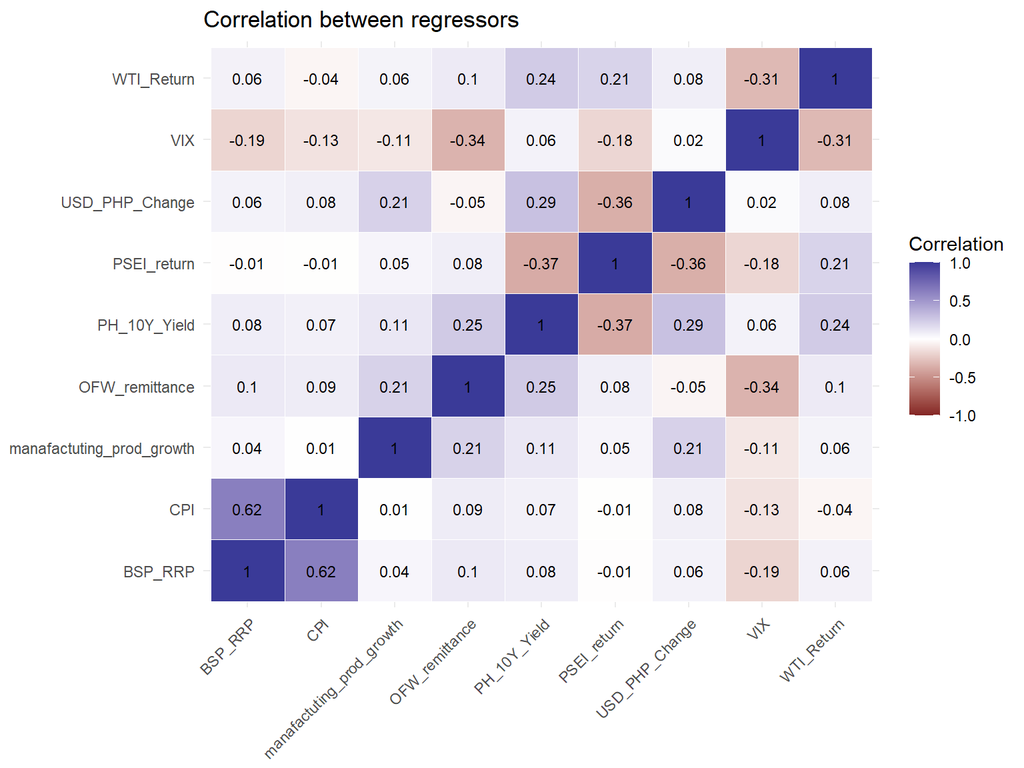

```r
regressor_correlations |>
  as.data.frame() |>
  rownames_to_column("Variable_1") |>
  pivot_longer(-Variable_1, names_to = "Variable_2", values_to = "Correlation") |>
  ggplot(aes(Variable_1, Variable_2, fill = Correlation)) +
  geom_tile(colour = "white") +
  geom_text(aes(label = round(Correlation, 2)), size = 3) +
  scale_fill_gradient2(midpoint = 0, limits = c(-1, 1)) +   # <- default colors
  labs(title = "Correlation between regressors", x = NULL, y = NULL) +
  theme_minimal() +
  theme(axis.text.x = element_text(angle = 45, hjust = 1))
```

```r
# VIF computed directly: regress each factor on all the other factors
vif_results <- tibble(term = regressor_names) |>
  mutate(
    Auxiliary_R2 = vapply(
      term,
      function(variable) {
        others <- setdiff(regressor_names, variable)
        summary(lm(reformulate(others, response = variable), data = model_data))$r.squared
      },
      numeric(1)
    ),
    VIF = 1 / (1 - Auxiliary_R2),
    Assessment = case_when(
      VIF > 10 ~ "Serious multicollinearity",
      VIF > 5  ~ "Moderate concern",
      TRUE     ~ "No concern"
    )
  )

vif_results |>
  flextable::flextable()
```

| term | Auxiliary_R2 | VIF | Assessment |
| --- | --- | --- | --- |
| PSEI_return | 0.3341041 | 1.501736 | No concern |
| BSP_RRP | 0.4065734 | 1.685128 | No concern |
| PH_10Y_Yield | 0.3681664 | 1.582695 | No concern |
| CPI | 0.4047664 | 1.680013 | No concern |
| OFW_remittance | 0.2512010 | 1.335472 | No concern |
| manafactuting_prod_growth | 0.1138538 | 1.128482 | No concern |
| USD_PHP_Change | 0.2303701 | 1.299326 | No concern |
| WTI_Return | 0.2764800 | 1.382132 | No concern |
| VIX | 0.2684638 | 1.366986 | No concern |

## 5.2 Heteroskedasticity

Heteroskedasticity means the spread of the errors changes across observations, for example larger errors in volatile months. The coefficients stay unbiased, but the usual standard errors, and so the p-values and confidence intervals in section 3 can be wrong.

- **Residuals vs. fitted plot:** If the spread of points widens or narrows as fitted values change, that suggests heteroskedasticity.
- **Breusch-Pagan test:** Regresses the squared residuals on the factors. H0: the error variance is constant (homoskedastic). H1: the error variance depends on the factors.
- **White test:** Same idea, but also includes the squared factors, so it can detect non-linear patterns in the variance.

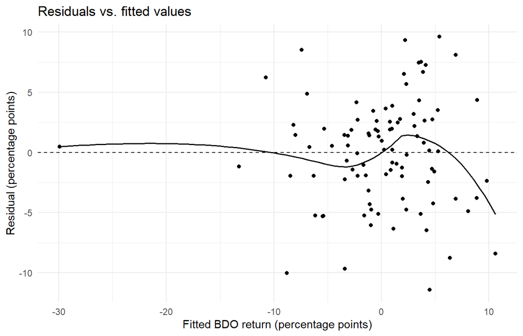

```r
tibble(Fitted = diag_fitted, Residual = diag_resid) |>
  ggplot(aes(Fitted, Residual)) +
  geom_hline(yintercept = 0, linetype = "dashed") +
  geom_point() +
  geom_smooth(method = "loess", se = FALSE, colour = "black", linewidth = 0.6) +
  labs(title = "Residuals vs. fitted values",
       x = "Fitted BDO return (percentage points)",
       y = "Residual (percentage points)") +
  theme_minimal()
```

```r
# Breusch-Pagan: squared residuals on the original factors
bp_test <- lmtest::bptest(baseline_lm)

# White test: squared residuals on the factors and their squares
white_formula <- as.formula(paste(
  "~", paste(regressor_names, collapse = " + "), "+",
  paste0("I(", regressor_names, "^2)", collapse = " + ")
))
white_test <- lmtest::bptest(baseline_lm, white_formula, data = model_data)

heteroskedasticity_results <- tibble(
  Test = c("Breusch-Pagan", "White (with squared terms)"),
  Statistic = c(unname(bp_test$statistic), unname(white_test$statistic)),
  DF = c(unname(bp_test$parameter), unname(white_test$parameter)),
  p.value = c(bp_test$p.value, white_test$p.value)
) |>
  mutate(
    Decision = if_else(
      p.value < inference_alpha,
      "Reject H0; evidence of heteroskedasticity",
      "Fail to reject H0; no evidence of heteroskedasticity"
    )
  )

heteroskedasticity_results |>
  mutate(p.value = format.pval(p.value, digits = 3, eps = 0.0001)) |>
  flextable::flextable()
```

| Test | Statistic | DF | p.value | Decision |
| --- | --- | --- | --- | --- |
| Breusch-Pagan | 11.47465 | 9 | 0.245 | Fail to reject H0; no evidence of heteroskedasticity |
| White (with squared terms) | 16.26108 | 18 | 0.574 | Fail to reject H0; no evidence of heteroskedasticity |

## 5.3 Autocorrelation

The data are monthly, so this month’s error may be related to last month’s error. If so, the usual standard errors are again unreliable.

- **Residuals over time and ACF plot:** The ACF (autocorrelation function) shows the correlation between residuals and their own past values. Bars outside the dashed bands suggest autocorrelation at that lag.
- **Durbin-Watson test:** Checks for first-order autocorrelation (this month vs. last month). A value near 2 means no autocorrelation.
- **Breusch-Godfrey test:** Checks for autocorrelation at several lags at once. Lag 1 and lag 12 (one year of monthly data) are tested. H0: no autocorrelation up to that lag. H1: some autocorrelation exists.

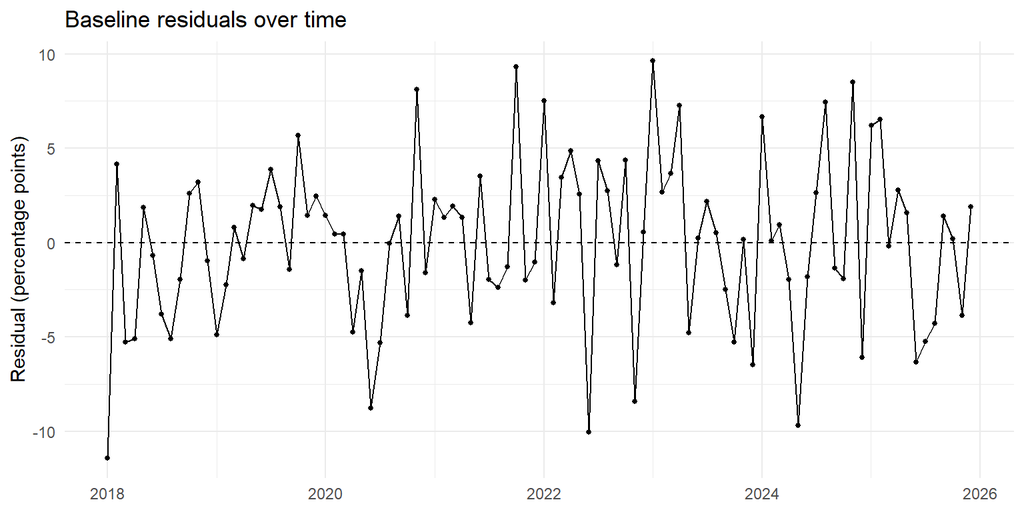

```r
tibble(Month = as.Date(diag_months), Residual = diag_resid) |>
  ggplot(aes(Month, Residual)) +
  geom_hline(yintercept = 0, linetype = "dashed") +
  geom_line() +
  geom_point(size = 1) +
  labs(title = "Baseline residuals over time",
       x = NULL, y = "Residual (percentage points)") +
  theme_minimal()
```

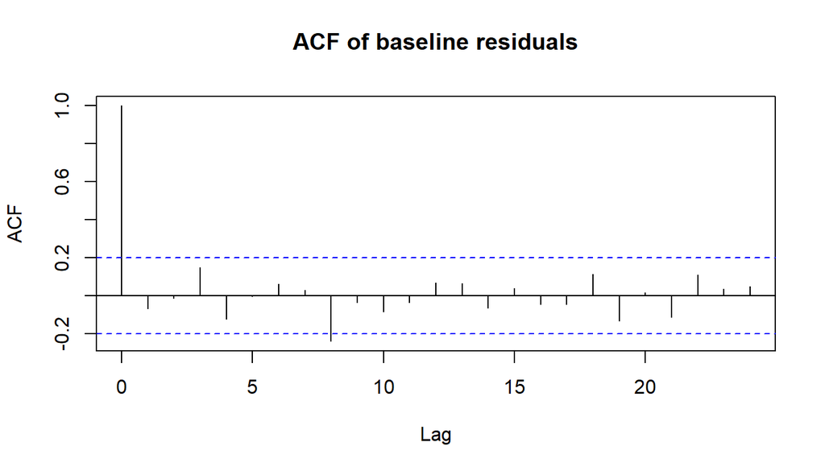

```r
acf(diag_resid, lag.max = 24, main = "ACF of baseline residuals")
```

```r
dw_test   <- lmtest::dwtest(baseline_lm, alternative = "two.sided")
bg_test_1 <- lmtest::bgtest(baseline_lm, order = 1)
bg_test_12 <- lmtest::bgtest(baseline_lm, order = 12)

autocorrelation_results <- tibble(
  Test = c("Durbin-Watson (first order)",
           "Breusch-Godfrey (up to lag 1)",
           "Breusch-Godfrey (up to lag 12)"),
  Statistic = c(unname(dw_test$statistic),
                unname(bg_test_1$statistic),
                unname(bg_test_12$statistic)),
  p.value = c(dw_test$p.value, bg_test_1$p.value, bg_test_12$p.value)
) |>
  mutate(
    Decision = if_else(
      p.value < inference_alpha,
      "Reject H0; evidence of autocorrelation",
      "Fail to reject H0; no evidence of autocorrelation"
    )
  )

autocorrelation_results |>
  mutate(p.value = format.pval(p.value, digits = 3, eps = 0.0001)) |>
  flextable::flextable()
```

| Test | Statistic | p.value | Decision |
| --- | --- | --- | --- |
| Durbin-Watson (first order) | 2.0606490 | 0.982 | Fail to reject H0; no evidence of autocorrelation |
| Breusch-Godfrey (up to lag 1) | 0.4493868 | 0.503 | Fail to reject H0; no evidence of autocorrelation |
| Breusch-Godfrey (up to lag 12) | 13.2905259 | 0.348 | Fail to reject H0; no evidence of autocorrelation |

## 5.4 Outliers and Influential Observations

Some months may be unusual enough to pull the estimated coefficients toward them. Three measures are used:

- **Studentized residual:** How far a month’s actual return is from the model’s fit, in standard-error units. Values beyond 2 in absolute value are unusual; beyond 3 are outliers.
- **Leverage (hat value):** How unusual a month’s factor values are compared with the rest of the sample. Values above 2(k + 1)/n are high, where k is the number of slopes and n the number of months.
- **Cook’s distance:** Combines both, measuring how much all coefficients would change if that month were removed. Values above 4/n are flagged.

```r
leverage_cutoff <- 2 * (diag_k + 1) / diag_n
cooks_cutoff    <- 4 / diag_n

influence_table <- tibble(
  Month = format(diag_months),
  BDO_Return = model_data[[dep_var]],
  Studentized_Residual = rstudent(baseline_lm),
  Leverage = hatvalues(baseline_lm),
  Cooks_Distance = cooks.distance(baseline_lm)
) |>
  mutate(
    Large_Residual = abs(Studentized_Residual) > 2,
    High_Leverage  = Leverage > leverage_cutoff,
    Influential    = Cooks_Distance > cooks_cutoff
  )

tibble(
  Measure = c("Studentized residual beyond 2 in absolute value",
              "Leverage above 2(k + 1)/n",
              "Cook's distance above 4/n"),
  Cutoff = c(2, leverage_cutoff, cooks_cutoff),
  Months_Flagged = c(sum(influence_table$Large_Residual),
                     sum(influence_table$High_Leverage),
                     sum(influence_table$Influential))
) |>
  flextable::flextable()
```

| Measure | Cutoff | Months_Flagged |
| --- | --- | --- |
| Studentized residual beyond 2 in absolute value | 2.00000000 | 7 |
| Leverage above 2(k + 1)/n | 0.20833333 | 8 |
| Cook's distance above 4/n | 0.04166667 | 7 |

```r
# Every month flagged by at least one measure, most influential first
flagged_months <- influence_table |>
  filter(Large_Residual | High_Leverage | Influential) |>
  arrange(desc(Cooks_Distance))

flagged_months |>
  flextable::flextable()
```

| Month | BDO_Return | Studentized_Residual | Leverage | Cooks_Distance | Large_Residual | High_Leverage | Influential |
| --- | --- | --- | --- | --- | --- | --- | --- |
| Apr 2020 | -2.4482 | -1.4632099 | 0.50127386 | 0.212374411 | false | true | true |
| Jun 2020 | -2.4139 | -2.3048410 | 0.29231704 | 0.208953153 | true | true | true |
| Jan 2023 | 14.9952 | 2.3839314 | 0.20161536 | 0.136104008 | true | false | true |
| Nov 2022 | 2.1819 | -2.0992578 | 0.22269022 | 0.121441196 | true | true | true |
| Jul 2022 | 7.8304 | 1.2205408 | 0.40911289 | 0.102559809 | false | true | true |
| Jun 2022 | -18.8403 | -2.3466159 | 0.10519025 | 0.061510172 | true | false | true |
| Jan 2018 | -6.9456 | -2.6342140 | 0.06498115 | 0.045109439 | true | false | true |
| May 2020 | -0.6005 | -0.4861452 | 0.57302534 | 0.032002025 | false | true | false |
| May 2024 | -13.1028 | -2.1916306 | 0.05035106 | 0.024388588 | true | false | false |
| Aug 2021 | 7.4565 | -0.6261939 | 0.34218296 | 0.020542421 | false | true | false |
| Jul 2021 | -10.4162 | -0.5324902 | 0.37784185 | 0.017364637 | false | true | false |
| Oct 2021 | 11.5131 | 2.0836780 | 0.03198903 | 0.013811033 | true | false | false |
| Mar 2020 | -29.4842 | 0.1537948 | 0.57938873 | 0.003295576 | false | true | false |

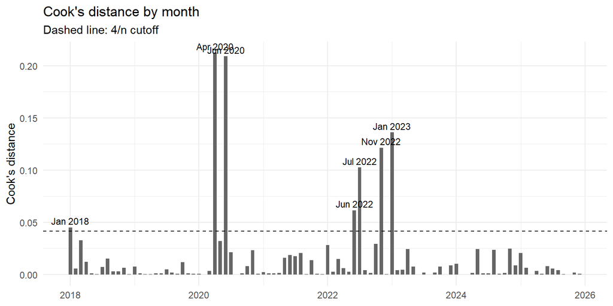

```r
influence_table |>
  mutate(Month = as.Date(diag_months)) |>
  ggplot(aes(Month, Cooks_Distance)) +
  geom_col(width = 20, fill = "grey40") +
  geom_hline(yintercept = cooks_cutoff, linetype = "dashed") +
  geom_text(
    data = ~ filter(.x, Influential),
    aes(label = format(as.yearmon(Month))),
    vjust = -0.4, size = 3
  ) +
  labs(title = "Cook's distance by month",
       subtitle = "Dashed line: 4/n cutoff",
       x = NULL, y = "Cook's distance") +
  theme_minimal()
```

The flagged months can be linked to known events, for example the COVID-19 lockdowns in 2020 and the 2022 rate-hiking cycle. The manufacturing growth variable is checked separately, because year-over-year growth produces extreme values when the comparison month was itself abnormal (a base effect).

```r
# Year-over-year manufacturing growth: months with extreme readings
model_data |>
  mutate(Month = format(diag_months)) |>
  filter(abs(manafactuting_prod_growth) > 40) |>
  select(Month, manafactuting_prod_growth) |>
  flextable::flextable()
```

| Month | manafactuting_prod_growth |
| --- | --- |
| Jul 2019 | -48.27 |
| Apr 2020 | -64.84 |
| May 2020 | -73.23 |
| Jun 2020 | -80.64 |
| Jul 2020 | -72.78 |
| Aug 2020 | -82.17 |
| Sep 2020 | -56.71 |
| Feb 2021 | -42.84 |
| Mar 2021 | -73.09 |
| Apr 2021 | 157.75 |
| May 2021 | 267.24 |
| Jun 2021 | 448.22 |
| Jul 2021 | 534.39 |
| Aug 2021 | 533.73 |
| Sep 2021 | 124.34 |
| Feb 2022 | 69.69 |
| Mar 2022 | 346.05 |

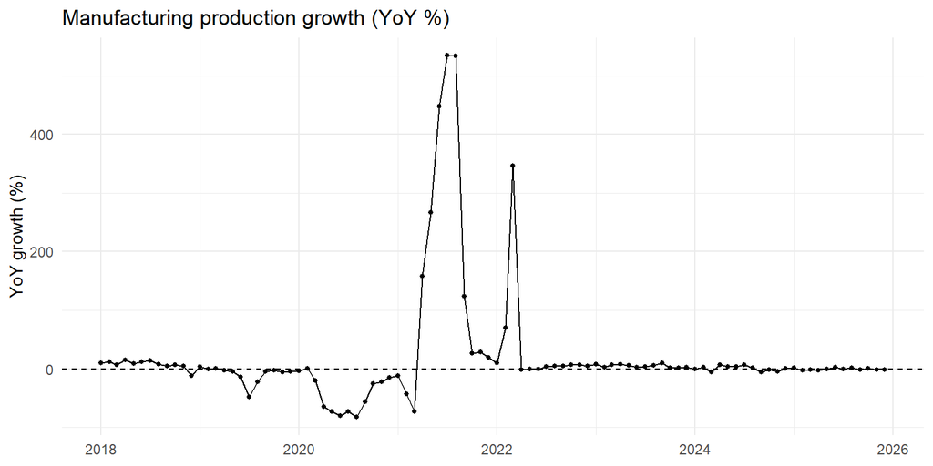

```r
tibble(Month = as.Date(diag_months),
       Manufacturing_YoY = model_data$manafactuting_prod_growth) |>
  ggplot(aes(Month, Manufacturing_YoY)) +
  geom_hline(yintercept = 0, linetype = "dashed") +
  geom_line() +
  geom_point(size = 1) +
  labs(title = "Manufacturing production growth (YoY %)",
       x = NULL, y = "YoY growth (%)") +
  theme_minimal()
```

## 5.5 Residual Diagnostics

Two more checks on the residuals:

- **Normality:** The t-tests and F-tests in 4.3 assume normally distributed errors. This matters less in larger samples, but with 96 months it is still worth checking. The Q-Q plot compares the residuals with a normal distribution; points on the line mean the residuals look normal. Shapiro-Wilk and Jarque-Bera (based on skewness and kurtosis) test H0: the residuals are normally distributed.
- **Functional form (Ramsey RESET):** Checks whether adding squared and cubed fitted values improves the model. H0: the linear form is adequate. H1: the model is missing a non-linear relationship.

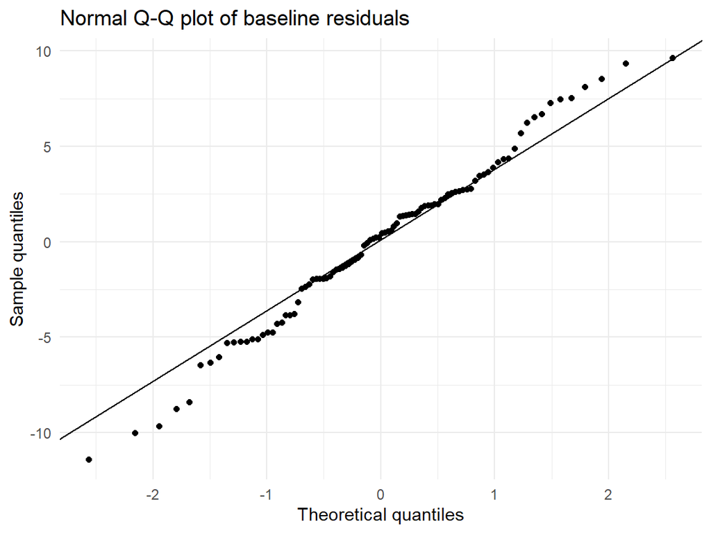

```r
tibble(Residual = diag_resid) |>
  ggplot(aes(sample = Residual)) +
  stat_qq() +
  stat_qq_line() +
  labs(title = "Normal Q-Q plot of baseline residuals",
       x = "Theoretical quantiles", y = "Sample quantiles") +
  theme_minimal()
```

```r
shapiro_result <- shapiro.test(diag_resid)

# Jarque-Bera computed directly from skewness and excess kurtosis
jb_skew <- mean((diag_resid - mean(diag_resid))^3) / mean((diag_resid - mean(diag_resid))^2)^1.5
jb_kurt <- mean((diag_resid - mean(diag_resid))^4) / mean((diag_resid - mean(diag_resid))^2)^2
jb_stat <- diag_n / 6 * (jb_skew^2 + (jb_kurt - 3)^2 / 4)
jb_p    <- pchisq(jb_stat, df = 2, lower.tail = FALSE)

reset_result <- lmtest::resettest(baseline_lm, power = 2:3, type = "fitted")

residual_test_results <- tibble(
  Test = c("Shapiro-Wilk (normality)",
           "Jarque-Bera (normality)",
           "Ramsey RESET (functional form)"),
  Statistic = c(unname(shapiro_result$statistic), jb_stat,
                unname(reset_result$statistic)),
  p.value = c(shapiro_result$p.value, jb_p, reset_result$p.value)
) |>
  mutate(
    Decision = case_when(
      str_detect(Test, "RESET") & p.value < inference_alpha ~
        "Reject H0; evidence of a missing non-linear relationship",
      str_detect(Test, "RESET") ~
        "Fail to reject H0; linear form is adequate",
      p.value < inference_alpha ~
        "Reject H0; residuals are not normal",
      TRUE ~
        "Fail to reject H0; no evidence against normality"
    )
  )

residual_test_results |>
  mutate(p.value = format.pval(p.value, digits = 3, eps = 0.0001)) |>
  flextable::flextable()
```

| Test | Statistic | p.value | Decision |
| --- | --- | --- | --- |
| Shapiro-Wilk (normality) | 0.9884267 | 0.570 | Fail to reject H0; no evidence against normality |
| Jarque-Bera (normality) | 0.4017353 | 0.818 | Fail to reject H0; no evidence against normality |
| Ramsey RESET (functional form) | 1.0978427 | 0.338 | Fail to reject H0; linear form is adequate |

```r
tibble(Skewness = jb_skew, Kurtosis = jb_kurt) |>
  flextable::flextable()
```

| Skewness | Kurtosis |
| --- | --- |
| -0.1506123 | 2.901524 |

## 5.6 Summary of Diagnostic Findings

```r
diagnostic_summary <- tibble(
  Issue = c("Multicollinearity",
            "Heteroskedasticity",
            "Autocorrelation",
            "Outliers / influential months",
            "Normality of residuals",
            "Functional form"),
  Evidence = c(
    sprintf("Max VIF = %.2f; max |correlation| = %.2f",
            max(vif_results$VIF), max(abs(correlation_pairs$Correlation))),
    sprintf("Breusch-Pagan p = %.3f; White p = %.3f",
            bp_test$p.value, white_test$p.value),
    sprintf("DW = %.2f; BG(1) p = %.3f; BG(12) p = %.3f",
            dw_test$statistic, bg_test_1$p.value, bg_test_12$p.value),
    sprintf("%d months above Cook's 4/n; %d high-leverage months",
            sum(influence_table$Influential), sum(influence_table$High_Leverage)),
    sprintf("Shapiro-Wilk p = %.3f; Jarque-Bera p = %.3f",
            shapiro_result$p.value, jb_p),
    sprintf("RESET p = %.3f", reset_result$p.value)
  ),
  Problem_Detected = c(
    if_else(max(vif_results$VIF) > 5, "Yes", "No"),
    if_else(min(bp_test$p.value, white_test$p.value) < inference_alpha, "Yes", "No"),
    if_else(min(dw_test$p.value, bg_test_1$p.value, bg_test_12$p.value) < inference_alpha, "Yes", "No"),
    if_else(sum(influence_table$Influential) > 0, "Yes", "No"),
    if_else(min(shapiro_result$p.value, jb_p) < inference_alpha, "Yes", "No"),
    if_else(reset_result$p.value < inference_alpha, "Yes", "No")
  )
)

diagnostic_summary |>
  flextable::flextable()
```

| Issue | Evidence | Problem_Detected |
| --- | --- | --- |
| Multicollinearity | Max VIF = 1.69; max \|correlation\| = 0.62 | No |
| Heteroskedasticity | Breusch-Pagan p = 0.245; White p = 0.574 | No |
| Autocorrelation | DW = 2.06; BG(1) p = 0.503; BG(12) p = 0.348 | No |
| Outliers / influential months | 7 months above Cook's 4/n; 8 high-leverage months | Yes |
| Normality of residuals | Shapiro-Wilk p = 0.570; Jarque-Bera p = 0.818 | No |
| Functional form | RESET p = 0.338 | No |

# Section 6 - Model Improvement

This section responds to the problems found in Section 5. Each remedy is applied only where the diagnostics or the data justify it, and the improved model is then compared with the baseline.

## 6.1 Problems Addressed and Remedies

```r
tibble(
  Problem = c(
    "Extreme manufacturing growth values (base effects from the 2020 lockdowns)",
    "Influential crisis months (Cook's distance above 4/n)",
    "Standard errors may be affected by heteroskedasticity or autocorrelation the tests could not detect"
  ),
  Remedy = c(
    "Winsorize manufacturing growth at its 5th and 95th percentiles",
    "Keep the months in the model; refit without them as a sensitivity check",
    "Report Newey-West (HAC) robust standard errors"
  ),
  Why = c(
    sprintf("Readings as high as %+.0f%% reflect a collapsed 2020 base, not real expansion, and raise the leverage of the 2021 months that carry them",
            max(model_data$manafactuting_prod_growth)),
    "They are real market events (e.g., COVID-19, 2022 rate hikes); deleting them would hide risk an investor actually faces",
    "HAC standard errors stay valid whether or not these problems are present, so inference does not depend on the tests having enough power with 96 months"
  )
) |>
  flextable::flextable()
```

| Problem | Remedy | Why |
| --- | --- | --- |
| Extreme manufacturing growth values (base effects from the 2020 lockdowns) | Winsorize manufacturing growth at its 5th and 95th percentiles | Readings as high as +534% reflect a collapsed 2020 base, not real expansion, and raise the leverage of the 2021 months that carry them |
| Influential crisis months (Cook's distance above 4/n) | Keep the months in the model; refit without them as a sensitivity check | They are real market events (e.g., COVID-19, 2022 rate hikes); deleting them would hide risk an investor actually faces |
| Standard errors may be affected by heteroskedasticity or autocorrelation the tests could not detect | Report Newey-West (HAC) robust standard errors | HAC standard errors stay valid whether or not these problems are present, so inference does not depend on the tests having enough power with 96 months |

## 6.2 Remedy 1: Winsorizing Manufacturing Growth

Winsorizing replaces values below the 5th percentile with the 5th percentile, and values above the 95th percentile with the 95th percentile. The month stays in the sample; only its extreme value is capped.

```r
manufacturing_limits <- quantile(
  model_data$manafactuting_prod_growth,
  probs = c(0.05, 0.95)
)

improved_data <- model_data |>
  mutate(
    manafactuting_prod_growth = pmin(
      pmax(manafactuting_prod_growth, manufacturing_limits[1]),
      manufacturing_limits[2]
    )
  )

tibble(
  Statistic = c("5th percentile cap", "95th percentile cap",
                "Months capped", "Original min", "Original max",
                "Winsorized min", "Winsorized max"),
  Value = c(manufacturing_limits[1], manufacturing_limits[2],
            sum(model_data$manafactuting_prod_growth != improved_data$manafactuting_prod_growth),
            min(model_data$manafactuting_prod_growth), max(model_data$manafactuting_prod_growth),
            min(improved_data$manafactuting_prod_growth), max(improved_data$manafactuting_prod_growth))
) |>
  flextable::flextable()
```

| Statistic | Value |
| --- | --- |
| 5th percentile cap | -66.8250 |
| 95th percentile cap | 185.1225 |
| Months capped | 10.0000 |
| Original min | -82.1700 |
| Original max | 534.3900 |
| Winsorized min | -66.8250 |
| Winsorized max | 185.1225 |

```r
improved_lm <- lm(reformulate(".", response = dep_var), data = improved_data)
```

The table below shows how capping changes the leverage of the months whose manufacturing value was capped.

```r
tibble(
  Month = format(diag_months),
  Original_Value = model_data$manafactuting_prod_growth,
  Winsorized_Value = improved_data$manafactuting_prod_growth,
  Leverage_Before = hatvalues(baseline_lm),
  Leverage_After = hatvalues(improved_lm)
) |>
  filter(Original_Value != Winsorized_Value) |>
  mutate(Above_Cutoff_After = Leverage_After > leverage_cutoff) |>
  flextable::flextable()
```

| Month | Original_Value | Winsorized_Value | Leverage_Before | Leverage_After | Above_Cutoff_After |
| --- | --- | --- | --- | --- | --- |
| May 2020 | -73.23 | -66.8250 | 0.57302534 | 0.57294415 | true |
| Jun 2020 | -80.64 | -66.8250 | 0.29231704 | 0.30511414 | true |
| Jul 2020 | -72.78 | -66.8250 | 0.12399023 | 0.13987622 | false |
| Aug 2020 | -82.17 | -66.8250 | 0.08124094 | 0.08587899 | false |
| Mar 2021 | -73.09 | -66.8250 | 0.04973356 | 0.06897254 | false |
| May 2021 | 267.24 | 185.1225 | 0.14035150 | 0.19860173 | false |
| Jun 2021 | 448.22 | 185.1225 | 0.20349210 | 0.15012353 | false |
| Jul 2021 | 534.39 | 185.1225 | 0.37784185 | 0.25273921 | true |
| Aug 2021 | 533.73 | 185.1225 | 0.34218296 | 0.21109502 | true |
| Mar 2022 | 346.05 | 185.1225 | 0.17944003 | 0.21098287 | true |

## 6.3 Remedy 2: Newey-West (HAC) Robust Standard Errors

Newey-West standard errors adjust for both heteroskedasticity and autocorrelation (HAC). They do not change the coefficient estimates, only their standard errors, t-statistics and p-values. The number of lags follows the common rule of thumb floor(4(n/100)^(2/9)).

```r
hac_lag <- floor(4 * (nobs(improved_lm) / 100)^(2 / 9))

improved_vcov <- sandwich::NeweyWest(
  improved_lm,
  lag = hac_lag,
  prewhite = FALSE,
  adjust = TRUE
)

improved_results <- lmtest::coeftest(improved_lm, vcov. = improved_vcov) |>
  broom::tidy() |>
  left_join(
    lmtest::coefci(improved_lm, vcov. = improved_vcov, level = 1 - inference_alpha) |>
      as.data.frame() |>
      rownames_to_column("term") |>
      setNames(c("term", "conf.low", "conf.high")),
    by = "term"
  ) |>
  mutate(
    Decision = if_else(
      p.value < inference_alpha,
      "Reject H0; evidence of a linear association",
      "Fail to reject H0; insufficient evidence"
    )
  )

tibble(Setting = "Newey-West lags", Value = hac_lag) |>
  flextable::flextable()
```

| Setting | Value |
| --- | --- |
| Newey-West lags | 3 |

```r
improved_results |>
  mutate(p.value = format.pval(p.value, digits = 3, eps = 0.0001)) |>
  flextable::flextable()
```

| term | estimate | std.error | statistic | p.value | conf.low | conf.high | Decision |
| --- | --- | --- | --- | --- | --- | --- | --- |
| (Intercept) | 0.16665071 | 2.61839160 | 0.06364621 | 0.949 | -5.03853952 | 5.37184094 | Fail to reject H0; insufficient evidence |
| PSEI_return | 1.03961437 | 0.09947092 | 10.45144016 | <1e-04 | 0.84187272 | 1.23735601 | Reject H0; evidence of a linear association |
| BSP_RRP | -0.56589131 | 3.66195872 | -0.15453241 | 0.878 | -7.84562430 | 6.71384168 | Fail to reject H0; insufficient evidence |
| PH_10Y_Yield | -0.11736518 | 1.38834311 | -0.08453615 | 0.933 | -2.87729994 | 2.64256957 | Fail to reject H0; insufficient evidence |
| CPI | 0.32906949 | 0.44584260 | 0.73808444 | 0.462 | -0.55723626 | 1.21537524 | Fail to reject H0; insufficient evidence |
| OFW_remittance | 0.07572106 | 0.09742656 | 0.77721167 | 0.439 | -0.11795653 | 0.26939866 | Fail to reject H0; insufficient evidence |
| manafactuting_prod_growth | 0.00174571 | 0.00699145 | 0.24969207 | 0.803 | -0.01215283 | 0.01564425 | Fail to reject H0; insufficient evidence |
| USD_PHP_Change | 26.43685634 | 36.58328002 | 0.72264861 | 0.472 | -46.28829740 | 99.16201007 | Fail to reject H0; insufficient evidence |
| WTI_Return | 2.83161761 | 4.92859092 | 0.57452884 | 0.567 | -6.96609687 | 12.62933209 | Fail to reject H0; insufficient evidence |
| VIX | -0.06422536 | 0.09309517 | -0.68988923 | 0.492 | -0.24929244 | 0.12084172 | Fail to reject H0; insufficient evidence |

```r
# Joint test: do the eight non-PSEi factors add information, using HAC standard errors?
improved_market_lm <- lm(BDO_return ~ PSEI_return, data = improved_data)

hac_joint_test <- lmtest::waldtest(
  improved_market_lm,
  improved_lm,
  vcov = improved_vcov,
  test = "F"
)

tibble(
  Test = "Eight non-PSEi factors jointly zero (HAC)",
  F_Statistic = hac_joint_test$F[2],
  Numerator_DF = abs(hac_joint_test$Df[2]),
  p.value = hac_joint_test$`Pr(>F)`[2]
) |>
  mutate(
    Decision = if_else(
      p.value < inference_alpha,
      "Reject H0; the group adds explanatory information",
      "Fail to reject H0; insufficient evidence the group adds information"
    ),
    p.value = format.pval(p.value, digits = 3, eps = 0.0001)
  ) |>
  flextable::flextable()
```

| Test | F_Statistic | Numerator_DF | p.value | Decision |
| --- | --- | --- | --- | --- |
| Eight non-PSEi factors jointly zero (HAC) | 0.7904714 | 8 | 0.612 | Fail to reject H0; insufficient evidence the group adds information |

## 6.4 Remedy 3: Sensitivity to Influential Months

The improved model is refit without the months flagged by Cook’s distance in Section 5.4. If the main conclusions hold without them, the results do not depend on a few unusual months.

```r
influential_months <- influence_table |>
  filter(Influential) |>
  pull(Month)

sensitivity_lm <- lm(
  reformulate(".", response = dep_var),
  data = improved_data[!influence_table$Influential, ]
)

tibble(Months_Removed = paste(influential_months, collapse = ", "),
       Observations_Left = nobs(sensitivity_lm)) |>
  flextable::flextable()
```

| Months_Removed | Observations_Left |
| --- | --- |
| Jan 2018, Apr 2020, Jun 2020, Jun 2022, Jul 2022, Nov 2022, Jan 2023 | 89 |

## 6.5 Baseline vs. Improved Model

The table compares each coefficient across three versions:

- **Baseline:** Original model with ordinary (OLS) standard errors, as in section 3.
- **Improved:** Winsorized manufacturing growth with Newey-West standard errors.
- **Without influential months:** Improved specification refit without the Cook’s distance months, with Newey-West standard errors.

```r
tidy_with_vcov <- function(fit, vcov_matrix, label) {
  lmtest::coeftest(fit, vcov. = vcov_matrix) |>
    broom::tidy() |>
    transmute(
      term,
      !!paste0(label, "_Estimate") := estimate,
      !!paste0(label, "_SE")       := std.error,
      !!paste0(label, "_p")        := p.value
    )
}

sensitivity_vcov <- sandwich::NeweyWest(
  sensitivity_lm, lag = hac_lag, prewhite = FALSE, adjust = TRUE
)

coefficient_comparison <- tidy_with_vcov(baseline_lm, vcov(baseline_lm), "Baseline") |>
  left_join(tidy_with_vcov(improved_lm, improved_vcov, "Improved"), by = "term") |>
  left_join(tidy_with_vcov(sensitivity_lm, sensitivity_vcov, "NoInfluential"), by = "term") |>
  mutate(
    Same_Sign = sign(Baseline_Estimate) == sign(Improved_Estimate) &
                sign(Improved_Estimate) == sign(NoInfluential_Estimate),
    Same_5pct_Decision = (Baseline_p < inference_alpha) == (Improved_p < inference_alpha) &
                         (Improved_p < inference_alpha) == (NoInfluential_p < inference_alpha)
  )

coefficient_comparison |>
  mutate(across(ends_with("_p"), ~ format.pval(.x, digits = 3, eps = 0.0001))) |>
  flextable::flextable()
```

| term | Baseline_Estimate | Baseline_SE | Baseline_p | Improved_Estimate | Improved_SE | Improved_p | NoInfluential_Estimate | NoInfluential_SE | NoInfluential_p | Same_Sign | Same_5pct_Decision |
| --- | --- | --- | --- | --- | --- | --- | --- | --- | --- | --- | --- |
| (Intercept) | 0.1715732941 | 2.200267521 | 0.938 | 0.16665071 | 2.61839160 | 0.949 | -1.214588028 | 2.181331760 | 0.5792 | false | true |
| PSEI_return | 1.0407523713 | 0.112749956 | <1e-04 | 1.03961437 | 0.09947092 | <1e-04 | 1.084282254 | 0.090181261 | <1e-04 | true | true |
| BSP_RRP | -0.5526832478 | 2.805428873 | 0.844 | -0.56589131 | 3.66195872 | 0.878 | -0.467175164 | 3.204507938 | 0.8845 | true | true |
| PH_10Y_Yield | -0.1097244088 | 1.406460738 | 0.938 | -0.11736518 | 1.38834311 | 0.933 | 0.220193785 | 1.133792826 | 0.8465 | false | true |
| CPI | 0.3298283936 | 0.312597872 | 0.294 | 0.32906949 | 0.44584260 | 0.462 | 0.299126555 | 0.353958029 | 0.4006 | true | true |
| OFW_remittance | 0.0796097556 | 0.122061274 | 0.516 | 0.07572106 | 0.09742656 | 0.439 | 0.172282096 | 0.092476049 | 0.0662 | true | true |
| manafactuting_prod_growth | 0.0003631603 | 0.004891659 | 0.941 | 0.00174571 | 0.00699145 | 0.803 | -0.004915226 | 0.005971217 | 0.4129 | false | true |
| USD_PHP_Change | 27.2440866180 | 40.116996449 | 0.499 | 26.43685634 | 36.58328002 | 0.472 | 22.519033581 | 41.685887985 | 0.5906 | true | true |
| WTI_Return | 2.8152617910 | 4.451779865 | 0.529 | 2.83161761 | 4.92859092 | 0.567 | 5.346204441 | 4.853013120 | 0.2740 | true | true |
| VIX | -0.0648935870 | 0.082222611 | 0.432 | -0.06422536 | 0.09309517 | 0.492 | 0.018353146 | 0.081704433 | 0.8228 | false | true |

```r
fit_summary <- function(fit, label) {
  tibble(
    Model = label,
    N = nobs(fit),
    R_Squared = summary(fit)$r.squared,
    Adjusted_R_Squared = summary(fit)$adj.r.squared,
    AIC = AIC(fit),
    BIC = BIC(fit),
    Max_Leverage = max(hatvalues(fit)),
    Breusch_Pagan_p = lmtest::bptest(fit)$p.value,
    Breusch_Godfrey_12_p = lmtest::bgtest(fit, order = 12)$p.value
  )
}

bind_rows(
  fit_summary(baseline_lm, "Baseline"),
  fit_summary(improved_lm, "Improved"),
  fit_summary(sensitivity_lm, "Without influential months")
) |>
  flextable::flextable()
```

| Model | N | R_Squared | Adjusted_R_Squared | AIC | BIC | Max_Leverage | Breusch_Pagan_p | Breusch_Godfrey_12_p |
| --- | --- | --- | --- | --- | --- | --- | --- | --- |
| Baseline | 96 | 0.6134271 | 0.5729718 | 578.3721 | 606.5800 | 0.5793887 | 0.2445706 | 0.3482825 |
| Improved | 96 | 0.6135365 | 0.5730927 | 578.3450 | 606.5528 | 0.5812746 | 0.2539724 | 0.3437398 |
| Without influential months | 89 | 0.6838853 | 0.6478722 | 512.4092 | 539.7842 | 0.7031559 | 0.7734974 | 0.4774601 |

AIC and BIC for the model without influential months are not comparable with the other two, because it uses fewer observations. R-squared and fit measures are reported for completeness; the improved model is not chosen for a higher R-squared but because its inference is more reliable.

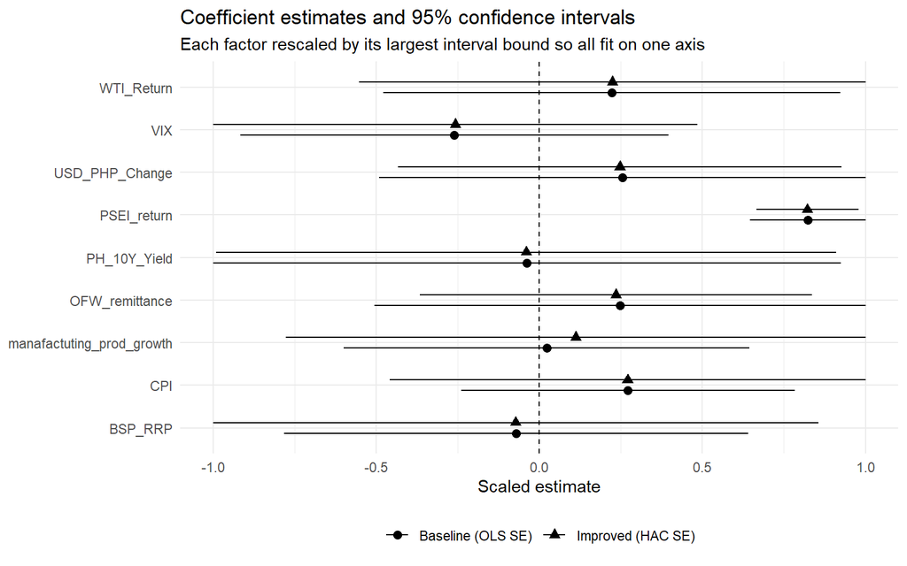

```r
# Coefficients with 95% confidence intervals: baseline (OLS) vs. improved (HAC)
bind_rows(
  broom::tidy(baseline_lm, conf.int = TRUE, conf.level = 1 - inference_alpha) |>
    mutate(Model = "Baseline (OLS SE)"),
  improved_results |>
    mutate(Model = "Improved (HAC SE)")
) |>
  filter(term != "(Intercept)") |>
  group_by(term) |>
  mutate(scale = max(abs(c(conf.low, conf.high)))) |>
  ungroup() |>
  mutate(across(c(estimate, conf.low, conf.high), ~ .x / scale)) |>
  ggplot(aes(estimate, term, shape = Model)) +
  geom_vline(xintercept = 0, linetype = "dashed") +
  geom_pointrange(aes(xmin = conf.low, xmax = conf.high),
                  position = position_dodge(width = 0.5)) +
  labs(title = "Coefficient estimates and 95% confidence intervals",
       subtitle = "Each factor rescaled by its largest interval bound so all fit on one axis",
       x = "Scaled estimate", y = NULL, shape = NULL) +
  theme_minimal() +
  theme(legend.position = "bottom")
```

```r
tibble(
  Check = c(
    "Coefficients that keep the same sign across all three versions",
    "Coefficients with the same 5% decision across all three versions",
    "Factors significant at 5% in the improved model (HAC)"
  ),
  Result = c(
    sprintf("%d of %d", sum(coefficient_comparison$Same_Sign), nrow(coefficient_comparison)),
    sprintf("%d of %d", sum(coefficient_comparison$Same_5pct_Decision), nrow(coefficient_comparison)),
    improved_results |>
      filter(term != "(Intercept)", p.value < inference_alpha) |>
      pull(term) |>
      paste(collapse = ", ")
  )
) |>
  flextable::flextable()
```

| Check | Result |
| --- | --- |
| Coefficients that keep the same sign across all three versions | 6 of 10 |
| Coefficients with the same 5% decision across all three versions | 10 of 10 |
| Factors significant at 5% in the improved model (HAC) | PSEI_return |

# Section 7 - Advanced Regression

The sensitivity check in section 6 showed that some coefficients (notably VIX and the 10Y yield change) changed sign when the crisis months were removed. This section tests directly whether BDO’s relationships behave differently during periods of market stress, using a **categorical (dummy) variable with interaction terms**.

## 7.1 Method and Stress-Period Definition

`Stress` equals 1 in two externally dated episodes and 0 otherwise:

- **COVID-19 shock:** March to December 2020 (lockdowns, market crash and recovery).
- **BSP tightening cycle:** May 2022 (first BSP rate hike) to October 2023 (last hike, the off-cycle increase to 6.50%).

The periods are dated from outside events, not from the Cook’s distance months in section 5.4, so the dummy is not fitted to the model’s own residuals. The improved specification from section 6.5 (winsorized manufacturing growth, Newey-West standard errors) is extended with:

```r
stress_periods <- tribble(
  ~Episode,                 ~Start,                   ~End,
  "COVID-19 shock",         as.yearmon("Mar 2020"),   as.yearmon("Dec 2020"),
  "BSP tightening cycle",   as.yearmon("May 2022"),   as.yearmon("Oct 2023")
)

in_stress <- function(months, periods) {
  Reduce(`|`, purrr::map2(periods$Start, periods$End,
                          ~ months >= .x & months <= .y))
}

# Same rows as improved_data (built from model_data, which has no missing values)
advanced_data <- improved_data |>
  mutate(Stress = as.numeric(in_stress(diag_months, stress_periods)))

stress_periods |>
  mutate(
    Months = purrr::map2_int(Start, End, ~ sum(diag_months >= .x & diag_months <= .y)),
    Start = format(Start), End = format(End)
  ) |>
  flextable::flextable()
```

| Episode | Start | End | Months |
| --- | --- | --- | --- |
| COVID-19 shock | Mar 2020 | Dec 2020 | 10 |
| BSP tightening cycle | May 2022 | Oct 2023 | 18 |

```r
# How BDO, the market and VIX behaved in calm versus stress months
advanced_data |>
  mutate(Period = if_else(Stress == 1, "Stress", "Calm")) |>
  group_by(Period) |>
  summarise(
    Months = n(),
    BDO_Mean = mean(BDO_return),
    BDO_SD = sd(BDO_return),
    PSEi_Mean = mean(PSEI_return),
    PSEi_SD = sd(PSEI_return),
    VIX_Mean = mean(VIX),
    .groups = "drop"
  ) |>
  flextable::flextable() |>
  flextable::colformat_double(digits = 3)
```

| Period | Months | BDO_Mean | BDO_SD | PSEi_Mean | PSEi_SD | VIX_Mean |
| --- | --- | --- | --- | --- | --- | --- |
| Calm | 68 | 0.125 | 5.580 | -0.408 | 4.104 | 17.595 |
| Stress | 28 | -0.331 | 9.983 | -0.246 | 7.226 | 24.920 |

## 7.2 Estimation

$$\begin{aligned}
\text{BDO}_t = {} & \beta_0 + \beta_1\,\text{PSEi}_t + \dots +
\beta_9\,\text{VIX}_t + \delta_0\,\text{Stress}_t \\
& + \delta_1\,(\text{PSEi}_t \times \text{Stress}_t) +
\delta_2\,(\text{VIX}_t \times \text{Stress}_t) +
\delta_3\,(\Delta\text{Y10}_t \times \text{Stress}_t) + u_t
\end{aligned}$$

In calm months the PSEi slope is $\beta_1$; in stress months it is $\beta_1 + \delta_1$. The same logic applies to VIX and the 10Y yield change.

```r
stress_lm <- lm(
  BDO_return ~ PSEI_return + BSP_RRP + PH_10Y_Yield + CPI + OFW_remittance +
    manafactuting_prod_growth + USD_PHP_Change + WTI_Return + VIX +
    Stress + PSEI_return:Stress + VIX:Stress + PH_10Y_Yield:Stress,
  data = advanced_data
)

stress_vcov <- sandwich::NeweyWest(stress_lm, lag = hac_lag, prewhite = FALSE, adjust = TRUE)

stress_results <- lmtest::coeftest(stress_lm, vcov. = stress_vcov) |>
  broom::tidy() |>
  left_join(
    lmtest::coefci(stress_lm, vcov. = stress_vcov, level = 1 - inference_alpha) |>
      as.data.frame() |>
      rownames_to_column("term") |>
      setNames(c("term", "conf.low", "conf.high")),
    by = "term"
  )

stress_terms <- c("Stress", "PSEI_return:Stress", "VIX:Stress", "PH_10Y_Yield:Stress")

stress_results |>
  mutate(p.value = format.pval(p.value, digits = 3, eps = 0.0001)) |>
  flextable::flextable() |>
  flextable::colformat_double(digits = 4) |>
  flextable::bold(i = ~ term %in% stress_terms)
```

| term | estimate | std.error | statistic | p.value | conf.low | conf.high |
| --- | --- | --- | --- | --- | --- | --- |
| (Intercept) | -3.5710 | 2.6676 | -1.3386 | 0.1844 | -8.8778 | 1.7358 |
| PSEI_return | 0.9662 | 0.1368 | 7.0613 | <1e-04 | 0.6940 | 1.2385 |
| BSP_RRP | -0.2874 | 3.7984 | -0.0757 | 0.9399 | -7.8436 | 7.2688 |
| PH_10Y_Yield | -0.3557 | 1.0451 | -0.3403 | 0.7345 | -2.4347 | 1.7234 |
| CPI | 0.2688 | 0.4587 | 0.5860 | 0.5595 | -0.6436 | 1.1812 |
| OFW_remittance | 0.0494 | 0.1021 | 0.4837 | 0.6299 | -0.1537 | 0.2525 |
| manafactuting_prod_growth | -0.0014 | 0.0058 | -0.2473 | 0.8053 | -0.0129 | 0.0101 |
| USD_PHP_Change | 28.5335 | 36.8692 | 0.7739 | 0.4412 | -44.8111 | 101.8781 |
| WTI_Return | 0.2104 | 4.9561 | 0.0425 | 0.9662 | -9.6489 | 10.0697 |
| VIX | 0.1725 | 0.1109 | 1.5558 | 0.1236 | -0.0481 | 0.3931 |
| Stress | 6.7800 | 3.4413 | 1.9702 | 0.0522 | -0.0659 | 13.6259 |
| PSEI_return:Stress | 0.1435 | 0.2180 | 0.6584 | 0.5121 | -0.2901 | 0.5772 |
| VIX:Stress | -0.3584 | 0.1488 | -2.4087 | 0.0182 | -0.6544 | -0.0624 |
| PH_10Y_Yield:Stress | 0.9350 | 2.7095 | 0.3451 | 0.7309 | -4.4551 | 6.3251 |

The table below converts the interaction terms into the slope that applies in each regime. The stress-period slope and its standard error come from the linear combination $\beta + \delta$ using the Newey-West covariance matrix.

```r
regime_slope <- function(fit, vc, main, interaction) {
  calm_est   <- coef(fit)[main]
  calm_se    <- sqrt(vc[main, main])
  idx        <- c(main, interaction)
  stress_est <- sum(coef(fit)[idx])
  stress_se  <- sqrt(sum(vc[idx, idx]))
  diff_p     <- 2 * pt(-abs(coef(fit)[interaction] / sqrt(vc[interaction, interaction])),
                       df.residual(fit))
  tibble(
    Factor = main,
    Calm_Slope = calm_est, Calm_SE = calm_se,
    Stress_Slope = stress_est, Stress_SE = stress_se,
    Difference = coef(fit)[interaction],
    Difference_p = diff_p
  )
}

regime_slopes <- bind_rows(
  regime_slope(stress_lm, stress_vcov, "PSEI_return",  "PSEI_return:Stress"),
  regime_slope(stress_lm, stress_vcov, "VIX",          "VIX:Stress"),
  regime_slope(stress_lm, stress_vcov, "PH_10Y_Yield", "PH_10Y_Yield:Stress")
)

regime_slopes |>
  mutate(Difference_p = format.pval(Difference_p, digits = 3, eps = 0.0001)) |>
  flextable::flextable() |>
  flextable::colformat_double(digits = 4)
```

| Factor | Calm_Slope | Calm_SE | Stress_Slope | Stress_SE | Difference | Difference_p |
| --- | --- | --- | --- | --- | --- | --- |
| PSEI_return | 0.9662 | 0.1368 | 1.1098 | 0.1782 | 0.1435 | 0.5121 |
| VIX | 0.1725 | 0.1109 | -0.1859 | 0.1083 | -0.3584 | 0.0182 |
| PH_10Y_Yield | -0.3557 | 1.0451 | 0.5793 | 2.8283 | 0.9350 | 0.7309 |

## 7.3 Do the Stress Terms Improve the Model?

- **H0:** $\delta_0 = \delta_1 = \delta_2 = \delta_3 = 0$ (BDO’s relationships are the same in calm and stress months).
- **H1:** At least one $\delta_j \neq 0$.

The test uses the Newey-West covariance matrix, matching section 6.

```r
stress_joint <- lmtest::waldtest(improved_lm, stress_lm, vcov = stress_vcov, test = "F")

tibble(
  Test = "All four stress terms jointly zero (HAC)",
  F_Statistic = stress_joint$F[2],
  Numerator_DF = abs(stress_joint$Df[2]),
  p.value = stress_joint$`Pr(>F)`[2]
) |>
  mutate(
    Decision = if_else(
      p.value < inference_alpha,
      "Reject H0; relationships differ in stress periods",
      "Fail to reject H0; insufficient evidence that relationships differ in stress periods"
    ),
    p.value = format.pval(p.value, digits = 3, eps = 0.0001)
  ) |>
  flextable::flextable()
```

| Test | F_Statistic | Numerator_DF | p.value | Decision |
| --- | --- | --- | --- | --- |
| All four stress terms jointly zero (HAC) | 1.764178 | 4 | 0.144 | Fail to reject H0; insufficient evidence that relationships differ in stress periods |

```r
bind_rows(
  fit_summary(improved_lm, "Improved (4.6)"),
  fit_summary(stress_lm,   "Improved + stress interactions")
) |>
  select(Model, N, R_Squared, Adjusted_R_Squared, AIC, BIC) |>
  flextable::flextable() |>
  flextable::colformat_double(digits = 4)
```

| Model | N | R_Squared | Adjusted_R_Squared | AIC | BIC |
| --- | --- | --- | --- | --- | --- |
| Improved (4.6) | 96 | 0.6135 | 0.5731 | 578.3450 | 606.5528 |
| Improved + stress interactions | 96 | 0.6348 | 0.5770 | 580.8999 | 619.3652 |

## 7.4 Robustness of the Stress Results

A single significant interaction could reflect a handful of months rather than a stable pattern. The model is re-estimated with each episode alone, with narrower and wider windows, and without the Cook’s distance months from section section 5.4. Individual p-values use Newey-West standard errors; the joint test is reported with both Newey-West (`Joint_HAC_p`) and ordinary (`Joint_OLS_p`) standard errors, because HAC standard errors can be too small when an interaction is identified by only a few months.

```r
stress_windows <- list(
  "Main definition"            = stress_periods,
  "COVID-19 only"              = stress_periods[1, ],
  "Tightening only"            = stress_periods[2, ],
  "Narrow (Mar-Jun 2020, May-Dec 2022)" = tibble(
    Start = as.yearmon(c("Mar 2020", "May 2022")),
    End   = as.yearmon(c("Jun 2020", "Dec 2022"))),
  "Wide (Feb 2020-Jun 2021, Apr 2022-Dec 2023)" = tibble(
    Start = as.yearmon(c("Feb 2020", "Apr 2022")),
    End   = as.yearmon(c("Jun 2021", "Dec 2023")))
)

robust_row <- function(data, label) {
  fit <- lm(formula(stress_lm), data = data)
  base_fit <- lm(formula(improved_lm), data = data)
  vc_hac <- sandwich::NeweyWest(fit, lag = hac_lag, prewhite = FALSE, adjust = TRUE)
  ct <- lmtest::coeftest(fit, vcov. = vc_hac)
  tibble(
    Version = label,
    N = nobs(fit),
    Stress_Months = as.integer(sum(data$Stress)),
    PSEi_x_Stress = ct["PSEI_return:Stress", 1],
    PSEi_x_Stress_p = ct["PSEI_return:Stress", 4],
    VIX_x_Stress = ct["VIX:Stress", 1],
    VIX_x_Stress_p = ct["VIX:Stress", 4],
    Y10_x_Stress = ct["PH_10Y_Yield:Stress", 1],
    Y10_x_Stress_p = ct["PH_10Y_Yield:Stress", 4],
    Joint_HAC_p = lmtest::waldtest(base_fit, fit, vcov = vc_hac, test = "F")$`Pr(>F)`[2],
    Joint_OLS_p = anova(base_fit, fit)$`Pr(>F)`[2]
  )
}

robustness_table <- bind_rows(
  purrr::imap_dfr(stress_windows, function(periods, label) {
    robust_row(
      improved_data |> mutate(Stress = as.numeric(in_stress(diag_months, periods))),
      label
    )
  }),
  robust_row(advanced_data[!influence_table$Influential, ],
             "Main definition, without Cook's distance months")
)

robustness_table |>
  mutate(across(ends_with("_p"), ~ format.pval(.x, digits = 3, eps = 0.0001))) |>
  flextable::flextable() |>
  flextable::colformat_double(digits = 3)
```

| Version | N | Stress_Months | PSEi_x_Stress | PSEi_x_Stress_p | VIX_x_Stress | VIX_x_Stress_p | Y10_x_Stress | Y10_x_Stress_p | Joint_HAC_p | Joint_OLS_p |
| --- | --- | --- | --- | --- | --- | --- | --- | --- | --- | --- |
| Main definition | 96 | 28 | 0.144 | 0.512 | -0.358 | 0.0182 | 0.935 | 0.73093 | 0.143979 | 0.319 |
| COVID-19 only | 96 | 10 | 0.159 | 0.400 | -0.233 | 0.1886 | 7.699 | 0.00244 | 0.000523 | 0.078 |
| Tightening only | 96 | 18 | 0.208 | 0.512 | 0.116 | 0.6341 | -4.330 | 0.16317 | 0.154978 | 0.289 |
| Narrow (Mar-Jun 2020, May-Dec 2022) | 96 | 12 | 0.116 | 0.664 | -0.125 | 0.5698 | 3.707 | 0.08923 | 0.062280 | 0.230 |
| Wide (Feb 2020-Jun 2021, Apr 2022-Dec 2023) | 96 | 38 | 0.027 | 0.901 | -0.299 | 0.1082 | 0.600 | 0.78144 | 0.491542 | 0.674 |
| Main definition, without Cook's distance months | 89 | 22 | 0.279 | 0.110 | -0.113 | 0.3066 | 2.446 | 0.44783 | 0.271277 | 0.630 |

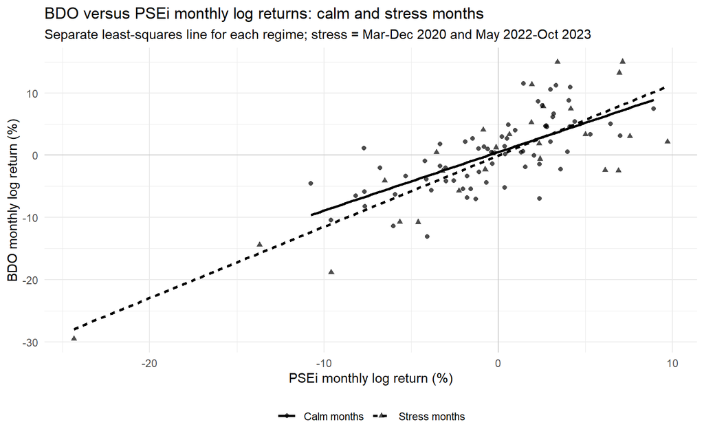

```r
# BDO against the market in calm and stress months, with a separate fitted line for each
advanced_data |>
  mutate(Period = if_else(Stress == 1, "Stress months", "Calm months")) |>
  ggplot(aes(PSEI_return, BDO_return, shape = Period, linetype = Period)) +
  geom_hline(yintercept = 0, colour = "grey80") +
  geom_vline(xintercept = 0, colour = "grey80") +
  geom_point(alpha = 0.7) +
  geom_smooth(method = "lm", se = FALSE, colour = "black", formula = y ~ x) +
  labs(
    title = "BDO versus PSEi monthly log returns: calm and stress months",
    subtitle = "Separate least-squares line for each regime; stress = Mar-Dec 2020 and May 2022-Oct 2023",
    x = "PSEi monthly log return (%)", y = "BDO monthly log return (%)",
    shape = NULL, linetype = NULL
  ) +
  theme_minimal() +
  theme(legend.position = "bottom")
```

## 7.5 Final Model Choice

```r
tibble(
  Criterion = c(
    "Joint test of stress terms (HAC)",
    "Change in market beta during stress",
    "VIX x Stress significant (HAC) under every robustness version",
    "AIC: improved vs. stress model",
    "Final model carried into section 8"
  ),
  Result = c(
    sprintf("F = %.2f, p = %.3f", stress_joint$F[2], stress_joint$`Pr(>F)`[2]),
    sprintf("%+.3f (p = %.3f)", regime_slopes$Difference[1], regime_slopes$Difference_p[1]),
    if_else(all(robustness_table$VIX_x_Stress_p < inference_alpha), "Yes", "No"),
    sprintf("%.2f vs. %.2f", AIC(improved_lm), AIC(stress_lm)),
    "Improved model from section 6 (winsorized manufacturing growth, Newey-West SEs)"
  )
) |>
  flextable::flextable()
```

| Criterion | Result |
| --- | --- |
| Joint test of stress terms (HAC) | F = 1.76, p = 0.144 |
| Change in market beta during stress | +0.144 (p = 0.512) |
| VIX x Stress significant (HAC) under every robustness version | No |
| AIC: improved vs. stress model | 578.34 vs. 580.90 |
| Final model carried into section 8 | Improved model from section 6 (winsorized manufacturing growth, Newey-West SEs) |

# Section 8 - Financial Interpretation

This section translates the final model (the improved model from section 6) into quantities an investor would use: BDO’s market beta, how much of its risk is market-driven, and what BDO’s return looks like under different market scenarios. All returns are monthly log returns in percent.

## 8.1 Market Beta

A beta of 1 means BDO moves one-for-one with the PSEi. The test below checks whether BDO is more or less sensitive to the market than that.

- **H0:** $\beta_{\text{PSEi}} = 1$ (BDO moves one-for-one with the market).
- **H1:** $\beta_{\text{PSEi}} \neq 1$.

```r
beta_hat <- coef(improved_lm)["PSEI_return"]
beta_se  <- sqrt(improved_vcov["PSEI_return", "PSEI_return"])
beta_t   <- (beta_hat - 1) / beta_se
beta_p   <- 2 * pt(-abs(beta_t), df.residual(improved_lm))
beta_ci  <- beta_hat + c(-1, 1) * qt(1 - inference_alpha / 2, df.residual(improved_lm)) * beta_se

tibble(
  Statistic = c("Beta estimate", "HAC standard error", "95% CI lower", "95% CI upper",
                "t-statistic (H0: beta = 1)", "p-value (H0: beta = 1)", "Decision"),
  Value = c(sprintf("%.4f", beta_hat), sprintf("%.4f", beta_se),
            sprintf("%.4f", beta_ci[1]), sprintf("%.4f", beta_ci[2]),
            sprintf("%.4f", beta_t), format.pval(beta_p, digits = 3, eps = 0.0001),
            if_else(beta_p < inference_alpha,
                    "Reject H0; beta differs from 1",
                    "Fail to reject H0; beta is statistically indistinguishable from 1"))
) |>
  flextable::flextable()
```

| Statistic | Value |
| --- | --- |
| Beta estimate | 1.0396 |
| HAC standard error | 0.0995 |
| 95% CI lower | 0.8419 |
| 95% CI upper | 1.2374 |
| t-statistic (H0: beta = 1) | 0.3983 |
| p-value (H0: beta = 1) | 0.691 |
| Decision | Fail to reject H0; beta is statistically indistinguishable from 1 |

## 8.2 Systematic versus Firm-Specific Risk

BDO’s total return variance is split into a market (systematic) part, $\hat\beta^2 \sigma^2_{\text{PSEi}}$, and a firm-specific (idiosyncratic) part, $\sigma^2_e$, using the market-only model on the same data. Monthly standard deviations are annualized by multiplying by $\sqrt{12}$.

```r
market_beta     <- coef(improved_market_lm)["PSEI_return"]
total_var       <- var(improved_data$BDO_return)
systematic_var  <- market_beta^2 * var(improved_data$PSEI_return)
idiosyncratic_var <- var(residuals(improved_market_lm))

tibble(
  Component = c("Total BDO risk", "Systematic (market) risk", "Firm-specific risk"),
  Monthly_Variance = c(total_var, systematic_var, idiosyncratic_var),
  Share_of_Total_Pct = 100 * c(1, systematic_var / total_var, idiosyncratic_var / total_var),
  Monthly_SD = sqrt(c(total_var, systematic_var, idiosyncratic_var)),
  Annualized_SD = sqrt(12) * sqrt(c(total_var, systematic_var, idiosyncratic_var))
) |>
  flextable::flextable() |>
  flextable::colformat_double(digits = 2)
```

| Component | Monthly_Variance | Share_of_Total_Pct | Monthly_SD | Annualized_SD |
| --- | --- | --- | --- | --- |
| Total BDO risk | 50.33 | 100.00 | 7.09 | 24.58 |
| Systematic (market) risk | 29.64 | 58.90 | 5.44 | 18.86 |
| Firm-specific risk | 20.68 | 41.10 | 4.55 | 15.75 |

## 8.3 Market Scenarios

Expected BDO return for given PSEi monthly returns, holding the other eight factors at their sample means. The confidence interval reflects uncertainty in the estimated average response (HAC); the prediction interval adds the month-to-month noise an investor would actually experience.

```r
scenario_pseis <- c(-10, -5, 0, 5, 10)

scenario_grid <- improved_data |>
  select(-all_of(dep_var)) |>
  summarise(across(everything(), mean)) |>
  slice(rep(1, length(scenario_pseis))) |>
  mutate(PSEI_return = scenario_pseis)

scenario_X  <- model.matrix(delete.response(terms(improved_lm)), scenario_grid)
scenario_fit <- drop(scenario_X %*% coef(improved_lm))
scenario_se  <- sqrt(rowSums((scenario_X %*% improved_vcov) * scenario_X))
scenario_pse <- sqrt(scenario_se^2 + sigma(improved_lm)^2)
t_crit <- qt(1 - inference_alpha / 2, df.residual(improved_lm))

tibble(
  PSEi_Return = scenario_pseis,
  Expected_BDO_Return = scenario_fit,
  CI_Lower = scenario_fit - t_crit * scenario_se,
  CI_Upper = scenario_fit + t_crit * scenario_se,
  PI_Lower = scenario_fit - t_crit * scenario_pse,
  PI_Upper = scenario_fit + t_crit * scenario_pse
) |>
  flextable::flextable() |>
  flextable::colformat_double(digits = 2)
```

| PSEi_Return | Expected_BDO_Return | CI_Lower | CI_Upper | PI_Lower | PI_Upper |
| --- | --- | --- | --- | --- | --- |
| -10.00 | -10.03 | -12.26 | -7.80 | -19.51 | -0.55 |
| -5.00 | -4.83 | -6.22 | -3.44 | -14.15 | 4.49 |
| 0.00 | 0.37 | -0.55 | 1.28 | -8.89 | 9.63 |
| 5.00 | 5.57 | 4.26 | 6.87 | -3.74 | 14.87 |
| 10.00 | 10.76 | 8.64 | 12.89 | 1.31 | 20.22 |

## 8.4 Summary of Findings for the Decision-Maker

```r
improved_results |>
  filter(term != "(Intercept)") |>
  left_join(factor_details |> select(term, Variable), by = "term") |>
  transmute(
    Factor = Variable,
    Estimate = estimate,
    HAC_p = p.value,
    Significant_5pct = if_else(p.value < inference_alpha, "Yes", "No"),
    Role = if_else(term == "PSEI_return",
                   "Dominant driver: BDO tracks the market",
                   "No reliable association beyond the market")
  ) |>
  mutate(HAC_p = format.pval(HAC_p, digits = 3, eps = 0.0001)) |>
  flextable::flextable() |>
  flextable::colformat_double(digits = 4)
```

| Factor | Estimate | HAC_p | Significant_5pct | Role |
| --- | --- | --- | --- | --- |
| PSEi return | 1.0396 | <1e-04 | Yes | Dominant driver: BDO tracks the market |
| BSP policy-rate change | -0.5659 | 0.878 | No | No reliable association beyond the market |
| PH 10Y yield change | -0.1174 | 0.933 | No | No reliable association beyond the market |
| CPI inflation | 0.3291 | 0.462 | No | No reliable association beyond the market |
| OFW remittance growth | 0.0757 | 0.439 | No | No reliable association beyond the market |
| Manufacturing growth | 0.0017 | 0.803 | No | No reliable association beyond the market |
| USD/PHP log change | 26.4369 | 0.472 | No | No reliable association beyond the market |
| WTI log return | 2.8316 | 0.567 | No | No reliable association beyond the market |
| VIX | -0.0642 | 0.492 | No | No reliable association beyond the market |